# Text Mining in R

Nov. 30, 2016

## R 語言簡介

- R語言自1993年問世，用於統計分析、繪圖、資料採礦、矩陣運算與機器學習等多個面向
- 兩大特色：免費下載、開放原始碼。
- 套件：ggmap, ggplot
- R Studio/R Pubs/GitHub
- [軟體安裝教學(R & SQL)](https://ling32342.github.io/2016_Workshop/2016_Install_tutorial.html)

## 字串處理

## 常用字串處理function

- nchar
- grep
- grepl
- regexpr
- sub
- gsub
- substr
- paste
- strsplit

## example

```r
> address <- c("臺北市文山區指南路二段91~120號"
+         ,"臺北市大同區重慶北路一段61~90號"
+         ,"臺北市文山區指南路三段1~30號"
+         ,"臺北市文山區指南路二段45巷31~60號"
+         ,"臺北市內湖區民權東路六段90巷6弄1~30號"
+         ,"臺北市文山區興隆路四段1~30號")
```

```r
> class(address)
```

```
[1] "character"
```

## nchar

計算字串長度

```r
> address
```

```
[1] "臺北市文山區指南路二段91~120號"        "臺北市大同區重慶北路一段61~90號"
[3] "臺北市文山區指南路三段1~30號"          "臺北市文山區指南路二段45巷31~60號"
[5] "臺北市內湖區民權東路六段90巷6弄1~30號" "臺北市文山區興隆路四段1~30號"
```

```r
> nchar(address)
```

```
[1] 18 18 16 20 22 16
```

## grep

grep第一個參數是pattern, 第二個是data,

output為有符合這個pattern是第幾筆資料

```r
> grep(pattern = "文山區", x = address)
```

```
[1] 1 3 4 6
```

```r
> grep("指南路", address)
```

```
[1] 1 3 4
```

## grep (2)

```r
> address
```

```
[1] "臺北市文山區指南路二段91~120號"        "臺北市大同區重慶北路一段61~90號"
[3] "臺北市文山區指南路三段1~30號"          "臺北市文山區指南路二段45巷31~60號"
[5] "臺北市內湖區民權東路六段90巷6弄1~30號" "臺北市文山區興隆路四段1~30號"
```

```r
> (a <- grep("指南路二段", address))
```

```
[1] 1 4
```

```r
> address[a]
```

```
[1] "臺北市文山區指南路二段91~120號"    "臺北市文山區指南路二段45巷31~60號"
```

## grepl

與grep用法相似,差異在於其output是TRUE/FALSE

```r
> grepl(pattern = "文山區", x = address)
```

```
[1]  TRUE FALSE  TRUE  TRUE FALSE  TRUE
```

```r
> grepl("指南路", address)
```

```
[1]  TRUE FALSE  TRUE  TRUE FALSE FALSE
```

## grepl (2)

```r
> address
```

```
[1] "臺北市文山區指南路二段91~120號"        "臺北市大同區重慶北路一段61~90號"
[3] "臺北市文山區指南路三段1~30號"          "臺北市文山區指南路二段45巷31~60號"
[5] "臺北市內湖區民權東路六段90巷6弄1~30號" "臺北市文山區興隆路四段1~30號"
```

```r
> (a <- grepl("指南路二段", address))
```

```
[1]  TRUE FALSE FALSE  TRUE FALSE FALSE
```

```r
> address[a]
```

```
[1] "臺北市文山區指南路二段91~120號"    "臺北市文山區指南路二段45巷31~60號"
```

## regexpr

找出**第一個**符合pattern的字串在哪個位置及長度,

如果不符合pattern,會顯示-1

```r
> address
```

```
[1] "臺北市文山區指南路二段91~120號"        "臺北市大同區重慶北路一段61~90號"
[3] "臺北市文山區指南路三段1~30號"          "臺北市文山區指南路二段45巷31~60號"
[5] "臺北市內湖區民權東路六段90巷6弄1~30號" "臺北市文山區興隆路四段1~30號"
```

```r
> regexpr(pattern = "指", text = address)
```

```
[1]  7 -1  7  7 -1 -1
attr(,"match.length")
[1]  1 -1  1  1 -1 -1
```

## regexpr (2)

```r
> regexpr(pattern = "指南路", text = address)
```

```
[1]  7 -1  7  7 -1 -1
attr(,"match.length")
[1]  3 -1  3  3 -1 -1
```

```r
> regexpr("指南路二段", address)
```

```
[1]  7 -1 -1  7 -1 -1
attr(,"match.length")
[1]  5 -1 -1  5 -1 -1
```

## regexpr (3)

```r
> regexpr("號", address)
```

```
[1] 18 18 16 20 22 16
attr(,"match.length")
[1] 1 1 1 1 1 1
```

```r
> regexpr("[0-9]", address)
```

```
[1] 12 13 12 12 13 12
attr(,"match.length")
[1] 1 1 1 1 1 1
```

## gregexpr

找出**所有**符合pattern的字串在哪個位置及長度

```r
> address
```

```
[1] "臺北市文山區指南路二段91~120號"        "臺北市大同區重慶北路一段61~90號"
[3] "臺北市文山區指南路三段1~30號"          "臺北市文山區指南路二段45巷31~60號"
[5] "臺北市內湖區民權東路六段90巷6弄1~30號" "臺北市文山區興隆路四段1~30號"
```

先回憶一下剛剛regexpr的結果

```r
> regexpr("[0-9]", address)
```

```
[1] 12 13 12 12 13 12
attr(,"match.length")
[1] 1 1 1 1 1 1
```

```r
> gregexpr("[0-9]", address)
```

```
[[1]]
[1] 12 13 15 16 17
attr(,"match.length")
[1] 1 1 1 1 1

[[2]]
[1] 13 14 16 17
attr(,"match.length")
[1] 1 1 1 1

[[3]]
[1] 12 14 15
attr(,"match.length")
[1] 1 1 1

[[4]]
[1] 12 13 15 16 18 19
attr(,"match.length")
[1] 1 1 1 1 1 1

[[5]]
[1] 13 14 16 18 20 21
attr(,"match.length")
[1] 1 1 1 1 1 1

[[6]]
[1] 12 14 15
attr(,"match.length")
[1] 1 1 1
```

## sub

sub指substitute,

把每個字串中**第一個**符合pattern的內容取代

```r
> sub(pattern = "指南路", replacement = "AAA", x = address)
```

```
[1] "臺北市文山區AAA二段91~120號"           "臺北市大同區重慶北路一段61~90號"
[3] "臺北市文山區AAA三段1~30號"             "臺北市文山區AAA二段45巷31~60號"
[5] "臺北市內湖區民權東路六段90巷6弄1~30號" "臺北市文山區興隆路四段1~30號"
```

```r
> sub("[0-9]", "X", address)
```

```
[1] "臺北市文山區指南路二段X1~120號"        "臺北市大同區重慶北路一段X1~90號"
[3] "臺北市文山區指南路三段X~30號"          "臺北市文山區指南路二段X5巷31~60號"
[5] "臺北市內湖區民權東路六段X0巷6弄1~30號" "臺北市文山區興隆路四段X~30號"
```

## gsub

把每個字串中**所有**符合pattern的內容取代

```r
> gsub(pattern = "指南路", replacement = "AAA", x = address)
```

```
[1] "臺北市文山區AAA二段91~120號"           "臺北市大同區重慶北路一段61~90號"
[3] "臺北市文山區AAA三段1~30號"             "臺北市文山區AAA二段45巷31~60號"
[5] "臺北市內湖區民權東路六段90巷6弄1~30號" "臺北市文山區興隆路四段1~30號"
```

```r
> gsub("[0-9]","X",address)
```

```
[1] "臺北市文山區指南路二段XX~XXX號"        "臺北市大同區重慶北路一段XX~XX號"
[3] "臺北市文山區指南路三段X~XX號"          "臺北市文山區指南路二段XX巷XX~XX號"
[5] "臺北市內湖區民權東路六段XX巷X弄X~XX號" "臺北市文山區興隆路四段X~XX號"
```

## substr

```r
> address
```

```
[1] "臺北市文山區指南路二段91~120號"        "臺北市大同區重慶北路一段61~90號"
[3] "臺北市文山區指南路三段1~30號"          "臺北市文山區指南路二段45巷31~60號"
[5] "臺北市內湖區民權東路六段90巷6弄1~30號" "臺北市文山區興隆路四段1~30號"
```

- 如果我只想要地址中的[行政區＋路段]

```r
> substr(address, start = 4, stop = 12)
```

```
[1] "文山區指南路二段9"  "大同區重慶北路一段" "文山區指南路三段1"  "文山區指南路二段4"
[5] "內湖區民權東路六段" "文山區興隆路四段1"
```

## substr (2)

結合regexpr

```r
> (a1 = regexpr("[0-9]",address))
```

```
[1] 12 13 12 12 13 12
attr(,"match.length")
[1] 1 1 1 1 1 1
```

```r
> (a2 = regexpr("號",address))
```

```
[1] 18 18 16 20 22 16
attr(,"match.length")
[1] 1 1 1 1 1 1
```

## substr (3)

```r
> substr(x = address, start = a1, stop = a2)
```

```
[1] "91~120號"      "61~90號"       "1~30號"        "45巷31~60號"   "90巷6弄1~30號" "1~30號"
```

```r
> substr(address, 4, a1)
```

```
[1] "文山區指南路二段9"   "大同區重慶北路一段6" "文山區指南路三段1"   "文山區指南路二段4"
[5] "內湖區民權東路六段9" "文山區興隆路四段1"
```

```r
> substr(address, 4, a1-1)
```

```
[1] "文山區指南路二段"   "大同區重慶北路一段" "文山區指南路三段"   "文山區指南路二段"
[5] "內湖區民權東路六段" "文山區興隆路四段"
```

## paste

字串的剪貼

```r
> paste("臺北市", substr(address, 4, a1-1), substr(x = address, start = a1, stop = a2))
```

```
[1] "臺北市 文山區指南路二段 91~120號"        "臺北市 大同區重慶北路一段 61~90號"
[3] "臺北市 文山區指南路三段 1~30號"          "臺北市 文山區指南路二段 45巷31~60號"
[5] "臺北市 內湖區民權東路六段 90巷6弄1~30號" "臺北市 文山區興隆路四段 1~30號"
```

```r
> paste("臺北市", substr(address, 4, a1-1),
+       substr(x = address, start = a1, stop = a2),sep = "")
```

```
[1] "臺北市文山區指南路二段91~120號"        "臺北市大同區重慶北路一段61~90號"
[3] "臺北市文山區指南路三段1~30號"          "臺北市文山區指南路二段45巷31~60號"
[5] "臺北市內湖區民權東路六段90巷6弄1~30號" "臺北市文山區興隆路四段1~30號"
```

```r
> # paste(..., sep="") 相當於 paste0(...)
```

## strsplit

字串的切割

```r
> strsplit(address,"市")
```

```
[[1]]
[1] "臺北"                     "文山區指南路二段91~120號"

[[2]]
[1] "臺北"                      "大同區重慶北路一段61~90號"

[[3]]
[1] "臺北"                   "文山區指南路三段1~30號"

[[4]]
[1] "臺北"                        "文山區指南路二段45巷31~60號"

[[5]]
[1] "臺北"                            "內湖區民權東路六段90巷6弄1~30號"

[[6]]
[1] "臺北"                   "文山區興隆路四段1~30號"
```

## Reference

- [正規表示式 Regular Expression](https://atedev.wordpress.com/2007/11/23/%E6%AD%A3%E8%A6%8F%E8%A1%A8%E7%A4%BA%E5%BC%8F-regular-expression/)
- [Stringr套件](http://blog.fens.me/r-stringr/)

## 文字處理

## 讀取資料

- readLines()
- 試讀[蔡英文總統就職演說中文全文](http://www.cna.com.tw/news/firstnews/201605205012-1.aspx)

```r
> readLines("Tsai.txt")
```

```
  [1] "各位友邦的元首與貴賓、各國駐台使節及代表、現場的好朋友，全體國人同胞，大家好"
  [2] ""
  [3] "感謝與承擔"
  [4] ""
  [5] "就在剛剛，我和陳建仁已經在總統府裡面，正式宣誓就任中華民國第十四任總統與副總統。我們要感謝這塊土地對我們的栽培，感謝人民對我們的信任，以及，最重要的，感謝這個國家的民主機制，讓我們透過和平的選舉過程，實現第三次政黨輪替，並且克服種種不確定因素，順利渡過長達四個月的交接期，完成政權和平移轉。"
  [6] ""
  [7] "台灣，再一次用行動告訴世界，作為一群民主人與自由人，我們有堅定的信念，去捍衛民主自由的生活方式。這段旅程，我們每一個人都參與其中。親愛的台灣人民，我們做到了。"
  [8] ""
  [9] "我要告訴大家，對於一月十六日的選舉結果，我從來沒有其他的解讀方式。人民選擇了新總統、新政府，所期待的就是四個字：解決問題。此時此刻，台灣的處境很困難，迫切需要執政者義無反顧的承擔。這一點，我不會忘記。"
 [10] ""
 [11] "我也要告訴大家，眼前的種種難關，需要我們誠實面對，需要我們共同承擔。所以，這個演說是一個邀請，我要邀請全體國人同胞一起來，扛起這個國家的未來。"
 [12] ""
 [13] "國家不會因為領導人而偉大；全體國民的共同奮鬥，才讓這個國家偉大。總統該團結的不只是支持者，總統該團結的是整個國家。團結是為了改變，這是我對這個國家最深切的期待。在這裡，我要誠懇地呼籲，請給這個國家一個機會，讓我們拋下成見，拋下過去的對立，我們一起來完成新時代交給我們的使命。"
 [14] ""
 [15] "在我們共同奮鬥的過程中，身為總統，我要向全國人民宣示，未來我和新政府，將領導這個國家的改革，展現決心，絕不退縮。"
 [16] ""
 [17] "為年輕人打造一個更好的國家"
 [18] ""
 [19] "未來的路並不好走，台灣需要一個正面迎向一切挑戰的新政府，我的責任就是領導這個新政府。"
 [20] ""
 [21] "我們的年金制度，如果不改，就會破產。"
 [22] "我們僵化的教育制度，已經逐漸與社會脈動脫節。"
 [23] "我們的能源與資源十分有限，我們的經濟缺乏動能，舊的代工模式已經面臨瓶頸，整個國家極需要新的經濟發展模式。"
 [24] "我們的人口結構急速老化，長照體系卻尚未健全。"
 [25] "我們的人口出生率持續低落，完善的托育制度卻始終遙遙無期。"
 [26] "我們環境汙染問題仍然嚴重。"
 [27] "我們國家的財政並不樂觀。"
 [28] "我們的司法已經失去人民的信任。"
 [29] "我們的食品安全問題，困擾著所有家庭。"
 [30] "我們的貧富差距越來越嚴重。"
 [31] "我們的社會安全網還是有很多破洞。"
 [32] "最重要的，我要特別強調，我們的年輕人處於低薪的處境，他們的人生，動彈不得，對於未來，充滿無奈與茫然。"
 [33] ""
 [34] "年輕人的未來是政府的責任。如果不友善的結構沒有改變，再多個人菁英的出現，都不足以讓整體年輕人的處境變好。我期許自己，在未來的任期之內，要一步一步，從根本的結構來解決這個國家的問題。"
 [35] ""
 [36] "這就是我想為台灣的年輕人做的事。雖然我沒有辦法立刻幫所有的年輕人加薪，但是我願意承諾，新政府會立刻展開行動。請給我們一點時間，也請跟我們一起走上改革的這一條路。"
 [37] ""
 [38] "改變年輕人的處境，就是改變國家的處境。一個國家的年輕人沒有未來，這個國家必定沒有未來。幫助年輕人突破困境，實現世代正義，把一個更好的國家交到下一代手上，就是新政府重大的責任。"
 [39] ""
 [40] "第一、經濟結構的轉型"
 [41] ""
 [42] "要打造一個更好的國家，未來，新政府要做到以下幾件事情。"
 [43] ""
 [44] "首先，就是讓台灣的經濟結構轉型。這是新政府所必須承擔的最艱鉅使命。我們不要妄自菲薄，更不要失去信心。台灣有很多別的國家沒有的優勢，我們有海洋經濟的活力和靭性，高素質的人力資源、務實可靠的工程師文化、完整的產業鏈、敏捷靈活的中小企業，以及，永不屈服的創業精神。 "
 [45] ""
 [46] "我們要讓台灣經濟脫胎換骨，就必須從現在起就下定決心，勇敢地走出另外一條路。這一條路，就是打造台灣經濟發展的新模式。"
 [47] ""
 [48] "新政府將打造一個以創新、就業、分配為核心價值，追求永續發展的新經濟模式。改革的第一步，就是強化經濟的活力與自主性，加強和全球及區域的連結，積極參與多邊及雙邊經濟合作及自由貿易談判，包括TPP、RCEP等，並且，推動新南向政策，提升對外經濟的格局及多元性，告別以往過於依賴單一市場的現象。 "
 [49] ""
 [50] "除此之外，新政府相信，唯有激發新的成長動能，我們才能突破當前經濟的停滯不前。我們會以出口和內需作為雙引擎，讓企業生產和人民生活互為表裡，讓對外貿易和在地經濟緊密連結。"
 [51] ""
 [52] "我們會優先推動五大創新研發計畫，藉著這些產業來重新塑造台灣的全球競爭力。我們也要積極提升勞動生產力，保障勞工權益，讓薪資和經濟成長能同步提升。"
 [53] ""
 [54] "這是台灣經濟發展的關鍵時刻。我們有決心，也有溝通能力。我們已經有系統性的規劃，未來，會以跨部會聯手的模式，把整個國家的力量集結起來，一起來催生這個新模式。"
 [55] ""
 [56] "在經濟發展的同時，我們不要忘記對環境的責任。經濟發展的新模式會和國土規劃、區域發展及環境永續，相互結合。產業的佈局和國土的利用，應該拋棄零碎的規畫，和短視近利的眼光。我們必須追求區域的均衡發展，這需要中央來規畫、整合，也需要地方政府充分發揮區域聯合治理的精神。 "
 [57] ""
 [58] "我們也不能再像過去，無止盡地揮霍自然資源及國民健康。所以，對各種汙染的控制，我們會嚴格把關，更要讓台灣走向循環經濟的時代，把廢棄物轉換為再生資源。對於能源的選擇，我們會以永續的觀念去逐步調整。新政府會嚴肅看待氣候變遷、國土保育、災害防治的相關議題，因為，我們只有一個地球，我們也只有一個台灣。"
 [59] ""
 [60] "第二、強化社會安全網"
 [61] ""
 [62] "新政府必須要承擔的第二件事情，就是強化台灣的社會安全網。這些年，幾件關於兒少安全及隨機殺人的事件，都讓整個社會震驚。不過，一個政府不能永遠在震驚，它必須要有同理心。沒有人可以替受害者家屬承受傷痛，但是，一個政府，尤其是第一線處理問題的人，必須要讓受害者以及家屬覺得，不幸事件發生的時候，政府是站在他們這一邊。"
 [63] ""
 [64] "除了同理心之外，政府更應該要提出解決的方法。全力防止悲劇一再發生，從治安、教育、心理健康、社會工作等各個面向，積極把破洞補起來。尤其是治安與反毒的工作，這些事情，新政府會用最嚴肅的態度和行動來面對。 "
 [65] ""
 [66] "在年金的改革方面，這是攸關台灣生存發展的關鍵改革，我們不應該遲疑，也不可以躁進。由陳建仁副總統擔任召集人的年金改革委員會，已經緊鑼密鼓在籌備之中。過去的政府在這個議題上，曾經有過一些努力。但是，缺乏社會的參與。新政府的做法，是發動一個集體協商，因為年金改革必須是一個透過協商來團結所有人的過程。"
 [67] ""
 [68] "這就是為什麼，我們要召開年金改革國是會議，由不同階層、不同職業代表，在社會團結的基礎上，共同協商。一年之內，我們會提出可行的改革方案。無論是勞工還是公務員，每一個國民的退休生活都應該得到公平的保障。"
 [69] ""
 [70] "另外，在長期照顧的議題上，我們將會把優質、平價、普及的長期照顧系統建立起來。和年金改革一樣，長照體系也是一個社會總動員的過程。新政府的做法是由政府主導和規劃，鼓勵民間發揮社區主義的精神，透過社會集體互助的力量，來建立一套妥善而完整的體系。每一個老年人都可以在自己熟悉的社區，安心享受老年生活，每一個家庭的照顧壓力將會減輕。照顧老人的工作不能完全讓它變成自由市場。我們會把責任扛起來，按部就班來規劃與執行，為超高齡社會的來臨，做好準備。 "
 [71] ""
 [72] "第三、社會的公平與正義"
 [73] ""
 [74] "新政府要承擔的第三件事情，就是社會的公平與正義。在這個議題上，新政府會持續和公民社會一起合作，讓台灣的政策更符合多元、平等、開放、透明、人權的價值，讓台灣的民主機制更加深化與進化。"
 [75] ""
 [76] "新的民主制度要能夠上路，我們必須先找出面對過去的共同方法。未來，我會在總統府成立真相與和解委員會，用最誠懇與謹慎的態度，來處理過去的歷史。追求轉型正義的目標是在追求社會的真正和解，讓所有台灣人都記取那個時代的錯誤。"
 [77] ""
 [78] "我們將從真相的調查與整理出發，預計在三年之內，完成台灣自己的轉型正義調查報告書。我們將會依據調查報告所揭示的真相，來進行後續的轉型正義工作。挖掘真相、彌平傷痕、釐清責任。從此以後，過去的歷史不再是台灣分裂的原因，而是台灣一起往前走的動力。"
 [79] ""
 [80] "同樣在公平正義的議題上，我會秉持相同的原則，來面對原住民族的議題。今天的就職典禮，原住民族的小朋友在唱國歌之前，先唱了他們部落傳統的古調。這象徵了，我們不敢忘記，這個島上先來後到的順序。 "
 [81] ""
 [82] "新政府會用道歉的態度，來面對原住民族相關議題，重建原民史觀，逐步推動自治，復育語言文化，提升生活照顧，這就是我要領導新政府推動的改變。"
 [83] ""
 [84] "接下來，新政府也會積極推動司法改革。這是現階段台灣人民最關心的議題。司法無法親近人民、不被人民信任、司法無法有效打擊犯罪，以及，司法失去作為正義最後一道防線的功能，是人民普遍的感受。"
 [85] ""
 [86] "為了展現新政府的決心，我們會在今年十月召開司法國是會議，透過人民實際的參與，讓社會力進來，一起推動司法改革。司法必須回應人民的需求，不再只是法律人的司法，而是全民的司法。司法改革也不只是司法人的家務事，而是全民參與的改革。這就是我對司法改革的期待。"
 [87] ""
 [88] "第四、區域的和平穩定發展及兩岸關係"
 [89] ""
 [90] "新政府要承擔的第四件事情，是區域的和平穩定與發展，以及妥善處理兩岸關係。過去三十年，無論是對亞洲或是全球，都是變動最劇烈的時期；而全球及區域的經濟穩定和集體安全，也是各國政府越來越關切的課題。"
 [91] ""
 [92] "台灣在區域發展當中，一直是不可或缺的關鍵角色。但是近年來，區域的情勢快速變動，如果台灣不善用自己的實力和籌碼，積極參與區域事務，不但將會變得無足輕重，甚至可能被邊緣化，喪失對於未來的自主權。"
 [93] ""
 [94] "我們有危機，但也有轉機。台灣現階段的經濟發展，和區域中許多國家高度關聯和互補。如果將打造經濟發展新模式的努力，透過和亞洲、乃至亞太區域的國家合作，共同形塑未來的發展策略，不但可以為區域的經濟創新、結構調整和永續發展，做出積極的貢獻，更可以和區域內的成員，建立緊密的「經濟共同體」意識。"
 [95] ""
 [96] "我們要和其他國家共享資源、人才與市場，擴大經濟規模，讓資源有效利用。「新南向政策」就是基於這樣的精神。我們會在科技、文化與經貿等各層面，和區域成員廣泛交流合作，尤其是增進與東協、印度的多元關係。為此，我們也願意和對岸，就共同參與區域發展的相關議題，坦誠交換意見，尋求各種合作與協力的可能性。"
 [97] ""
 [98] "在積極發展經濟的同時，亞太地區的安全情勢也變得越來越複雜，而兩岸關係，也成為建構區域和平與集體安全的重要一環。這個建構的進程，台灣會做一個「和平的堅定維護者」，積極參與，絕不缺席；我們也將致力維持兩岸關係的和平穩定；我們更會努力促成內部和解，強化民主機制，凝聚共識，形成一致對外的立場。"
 [99] ""
[100] "對話和溝通，是我們達成目標最重要的關鍵。台灣也要成為一個「和平的積極溝通者」，我們將和相關的各方，建立常態、緊密的溝通機制，隨時交換意見，防止誤判，建立互信，有效解決爭議。我們將謹守和平原則、利益共享原則，來處理相關的爭議。"
[101] ""
[102] "我依照中華民國憲法當選總統，我有責任捍衛中華民國的主權和領土；對於東海及南海問題，我們主張應擱置爭議，共同開發。"
[103] ""
[104] "兩岸之間的對話與溝通，我們也將努力維持現有的機制。1992年兩岸兩會秉持相互諒解、求同存異的政治思維，進行溝通協商，達成若干的共同認知與諒解，我尊重這個歷史事實。92年之後，20多年來雙方交流、協商所累積形成的現狀與成果，兩岸都應該共同珍惜與維護，並在這個既有的事實與政治基礎上，持續推動兩岸關係和平穩定發展；新政府會依據中華民國憲法、兩岸人民關係條例及其他相關法律，處理兩岸事務。兩岸的兩個執政黨應該要放下歷史包袱，展開良性對話，造福兩岸人民。"
[105] ""
[106] "我所講的既有政治基礎，包含幾個關鍵元素，第一，1992年兩岸兩會會談的歷史事實與求同存異的共同認知，這是歷史事實；第二，中華民國現行憲政體制；第三，兩岸過去20多年來協商和交流互動的成果；第四，台灣民主原則及普遍民意。"
[107] ""
[108] "第五、外交與全球性議題"
[109] ""
[110] "新政府要承擔的第五件事情，是善盡地球公民的責任，在外交與全球性的議題上做出貢獻。讓台灣走向世界，也要讓世界走進台灣。"
[111] ""
[112] "現場有許多來自各國的元首與使節團，我要特別謝謝他們，長久以來一直幫助台灣，讓我們有機會參與國際社會。未來，我們會持續透過官方互動、企業投資與民間合作各種方式，分享台灣發展的經驗，與友邦建立永續的夥伴關係。"
[113] ""
[114] "台灣是全球公民社會的模範生，民主化以來，我們始終堅持和平、自由、民主及人權的普世價值。我們會秉持這個精神，加入全球議題的價值同盟。我們會繼續深化與包括美國、日本、歐洲在內的友好民主國家的關係，在共同的價值基礎上，推動全方位的合作。"
[115] ""
[116] "我們會積極參與國際經貿合作及規則制定，堅定維護全球的經濟秩序，並且融入重要的區域經貿體系。我們也不會在防制全球暖化、氣候變遷的議題上缺席。我們將會在行政院設立專責的能源和減碳辦公室，並且根據COP21巴黎協議的規定，定期檢討溫室氣體的減量目標，與友好國家攜手，共同維護永續的地球。"
[117] ""
[118] "同時，新政府會支持並參與，全球性新興議題的國際合作，包括人道救援、醫療援助、疾病的防治與研究、反恐合作，以及共同打擊跨國犯罪，讓台灣成為國際社會不可或缺的夥伴。"
[119] ""
[120] "結語"
[121] ""
[122] "1996年台灣第一次總統直選，到今天剛好20年。過去20年，在幾任政府以及公民社會的努力之下，我們成功渡過了許多新興民主國家必須面對的難關。在這個過程中，我們曾經有過許多感動人心的時刻和故事，不過，正如同世界上其他國家一樣，我們也曾經有過焦慮、不安、矛盾、與對立。"
[123] ""
[124] "我們看到了社會的對立，進步與保守的對立，環境與開發的對立，以及，政治意識之間的對立。這些對立，曾經激發出選舉時的動員能量，不過也因為這些對立，我們的民主逐漸失去了解決問題的能力。"
[125] ""
[126] "民主是一個進程，每一個時代的政治工作者，都要清楚認識他身上所肩負的責任。民主會前進，民主也有可能倒退。今天，我站在這裡，就是要告訴大家，倒退不會是我們的選項。新政府的責任就是把台灣的民主推向下一個階段：以前的民主是選舉的輸贏，現在的民主則是關於人民的幸福；以前的民主是兩個價值觀的對決，現在的民主則是不同價值觀的對話。"
[127] ""
[128] "打造一個沒有被意識形態綁架的「團結的民主」，打造一個可以回應社會與經濟問題的「有效率的民主」，打造一個能夠實質照料人民的「務實的民主」，這就是新時代的意義。"
[129] ""
[130] "只要我們相信，新時代就會來臨。只要這個國家的主人，有堅定的信念，新時代一定會在我們這一代人的手上誕生。"
[131] ""
[132] "各位親愛的台灣人民，演講要結束了，改革要開始了。從這一刻起，這個國家的擔子交在新政府身上。我會讓大家看見這個國家的改變。"
[133] ""
[134] "歷史會記得我們這個勇敢的世代，這個國家的繁榮、尊嚴、團結、自信和公義，都有我們努力的痕跡。歷史會記得我們的勇敢，我們在2016年一起把國家帶向新的方向。這塊土地上的每一個人，都因為參與台灣的改變，而感到驕傲。"
[135] ""
[136] "剛才表演節目中的一首歌曲當中，有一句讓我很感動的歌詞："
[137] "（台語）現在是彼一天，勇敢ㄟ台灣人。"
[138] ""
[139] "各位國人同胞，兩千三百萬的台灣人民，等待已經結束，現在就是那一天。今天，明天，未來的每一天，我們都要做一個守護民主、守護自由、守護這個國家的台灣人。"
[140] ""
[141] "謝謝大家。"
```

## 資料處理

- 安裝套件

```r
> install.packages("tm")
```

- 載入套件

```r
> library("tm")
```

- 刪除標點符號與數字

```r
> removePunctuation()
> removeNumbers()
```

```r
> # 讀入資料
> (G <- readLines("Tsai.txt"))
```

```
  [1] "各位友邦的元首與貴賓、各國駐台使節及代表、現場的好朋友，全體國人同胞，大家好"
  [2] ""
  [3] "感謝與承擔"
  [4] ""
  [5] "就在剛剛，我和陳建仁已經在總統府裡面，正式宣誓就任中華民國第十四任總統與副總統。我們要感謝這塊土地對我們的栽培，感謝人民對我們的信任，以及，最重要的，感謝這個國家的民主機制，讓我們透過和平的選舉過程，實現第三次政黨輪替，並且克服種種不確定因素，順利渡過長達四個月的交接期，完成政權和平移轉。"
  [6] ""
  [7] "台灣，再一次用行動告訴世界，作為一群民主人與自由人，我們有堅定的信念，去捍衛民主自由的生活方式。這段旅程，我們每一個人都參與其中。親愛的台灣人民，我們做到了。"
  [8] ""
  [9] "我要告訴大家，對於一月十六日的選舉結果，我從來沒有其他的解讀方式。人民選擇了新總統、新政府，所期待的就是四個字：解決問題。此時此刻，台灣的處境很困難，迫切需要執政者義無反顧的承擔。這一點，我不會忘記。"
 [10] ""
 [11] "我也要告訴大家，眼前的種種難關，需要我們誠實面對，需要我們共同承擔。所以，這個演說是一個邀請，我要邀請全體國人同胞一起來，扛起這個國家的未來。"
 [12] ""
 [13] "國家不會因為領導人而偉大；全體國民的共同奮鬥，才讓這個國家偉大。總統該團結的不只是支持者，總統該團結的是整個國家。團結是為了改變，這是我對這個國家最深切的期待。在這裡，我要誠懇地呼籲，請給這個國家一個機會，讓我們拋下成見，拋下過去的對立，我們一起來完成新時代交給我們的使命。"
 [14] ""
 [15] "在我們共同奮鬥的過程中，身為總統，我要向全國人民宣示，未來我和新政府，將領導這個國家的改革，展現決心，絕不退縮。"
 [16] ""
 [17] "為年輕人打造一個更好的國家"
 [18] ""
 [19] "未來的路並不好走，台灣需要一個正面迎向一切挑戰的新政府，我的責任就是領導這個新政府。"
 [20] ""
 [21] "我們的年金制度，如果不改，就會破產。"
 [22] "我們僵化的教育制度，已經逐漸與社會脈動脫節。"
 [23] "我們的能源與資源十分有限，我們的經濟缺乏動能，舊的代工模式已經面臨瓶頸，整個國家極需要新的經濟發展模式。"
 [24] "我們的人口結構急速老化，長照體系卻尚未健全。"
 [25] "我們的人口出生率持續低落，完善的托育制度卻始終遙遙無期。"
 [26] "我們環境汙染問題仍然嚴重。"
 [27] "我們國家的財政並不樂觀。"
 [28] "我們的司法已經失去人民的信任。"
 [29] "我們的食品安全問題，困擾著所有家庭。"
 [30] "我們的貧富差距越來越嚴重。"
 [31] "我們的社會安全網還是有很多破洞。"
 [32] "最重要的，我要特別強調，我們的年輕人處於低薪的處境，他們的人生，動彈不得，對於未來，充滿無奈與茫然。"
 [33] ""
 [34] "年輕人的未來是政府的責任。如果不友善的結構沒有改變，再多個人菁英的出現，都不足以讓整體年輕人的處境變好。我期許自己，在未來的任期之內，要一步一步，從根本的結構來解決這個國家的問題。"
 [35] ""
 [36] "這就是我想為台灣的年輕人做的事。雖然我沒有辦法立刻幫所有的年輕人加薪，但是我願意承諾，新政府會立刻展開行動。請給我們一點時間，也請跟我們一起走上改革的這一條路。"
 [37] ""
 [38] "改變年輕人的處境，就是改變國家的處境。一個國家的年輕人沒有未來，這個國家必定沒有未來。幫助年輕人突破困境，實現世代正義，把一個更好的國家交到下一代手上，就是新政府重大的責任。"
 [39] ""
 [40] "第一、經濟結構的轉型"
 [41] ""
 [42] "要打造一個更好的國家，未來，新政府要做到以下幾件事情。"
 [43] ""
 [44] "首先，就是讓台灣的經濟結構轉型。這是新政府所必須承擔的最艱鉅使命。我們不要妄自菲薄，更不要失去信心。台灣有很多別的國家沒有的優勢，我們有海洋經濟的活力和靭性，高素質的人力資源、務實可靠的工程師文化、完整的產業鏈、敏捷靈活的中小企業，以及，永不屈服的創業精神。 "
 [45] ""
 [46] "我們要讓台灣經濟脫胎換骨，就必須從現在起就下定決心，勇敢地走出另外一條路。這一條路，就是打造台灣經濟發展的新模式。"
 [47] ""
 [48] "新政府將打造一個以創新、就業、分配為核心價值，追求永續發展的新經濟模式。改革的第一步，就是強化經濟的活力與自主性，加強和全球及區域的連結，積極參與多邊及雙邊經濟合作及自由貿易談判，包括TPP、RCEP等，並且，推動新南向政策，提升對外經濟的格局及多元性，告別以往過於依賴單一市場的現象。 "
 [49] ""
 [50] "除此之外，新政府相信，唯有激發新的成長動能，我們才能突破當前經濟的停滯不前。我們會以出口和內需作為雙引擎，讓企業生產和人民生活互為表裡，讓對外貿易和在地經濟緊密連結。"
 [51] ""
 [52] "我們會優先推動五大創新研發計畫，藉著這些產業來重新塑造台灣的全球競爭力。我們也要積極提升勞動生產力，保障勞工權益，讓薪資和經濟成長能同步提升。"
 [53] ""
 [54] "這是台灣經濟發展的關鍵時刻。我們有決心，也有溝通能力。我們已經有系統性的規劃，未來，會以跨部會聯手的模式，把整個國家的力量集結起來，一起來催生這個新模式。"
 [55] ""
 [56] "在經濟發展的同時，我們不要忘記對環境的責任。經濟發展的新模式會和國土規劃、區域發展及環境永續，相互結合。產業的佈局和國土的利用，應該拋棄零碎的規畫，和短視近利的眼光。我們必須追求區域的均衡發展，這需要中央來規畫、整合，也需要地方政府充分發揮區域聯合治理的精神。 "
 [57] ""
 [58] "我們也不能再像過去，無止盡地揮霍自然資源及國民健康。所以，對各種汙染的控制，我們會嚴格把關，更要讓台灣走向循環經濟的時代，把廢棄物轉換為再生資源。對於能源的選擇，我們會以永續的觀念去逐步調整。新政府會嚴肅看待氣候變遷、國土保育、災害防治的相關議題，因為，我們只有一個地球，我們也只有一個台灣。"
 [59] ""
 [60] "第二、強化社會安全網"
 [61] ""
 [62] "新政府必須要承擔的第二件事情，就是強化台灣的社會安全網。這些年，幾件關於兒少安全及隨機殺人的事件，都讓整個社會震驚。不過，一個政府不能永遠在震驚，它必須要有同理心。沒有人可以替受害者家屬承受傷痛，但是，一個政府，尤其是第一線處理問題的人，必須要讓受害者以及家屬覺得，不幸事件發生的時候，政府是站在他們這一邊。"
 [63] ""
 [64] "除了同理心之外，政府更應該要提出解決的方法。全力防止悲劇一再發生，從治安、教育、心理健康、社會工作等各個面向，積極把破洞補起來。尤其是治安與反毒的工作，這些事情，新政府會用最嚴肅的態度和行動來面對。 "
 [65] ""
 [66] "在年金的改革方面，這是攸關台灣生存發展的關鍵改革，我們不應該遲疑，也不可以躁進。由陳建仁副總統擔任召集人的年金改革委員會，已經緊鑼密鼓在籌備之中。過去的政府在這個議題上，曾經有過一些努力。但是，缺乏社會的參與。新政府的做法，是發動一個集體協商，因為年金改革必須是一個透過協商來團結所有人的過程。"
 [67] ""
 [68] "這就是為什麼，我們要召開年金改革國是會議，由不同階層、不同職業代表，在社會團結的基礎上，共同協商。一年之內，我們會提出可行的改革方案。無論是勞工還是公務員，每一個國民的退休生活都應該得到公平的保障。"
 [69] ""
 [70] "另外，在長期照顧的議題上，我們將會把優質、平價、普及的長期照顧系統建立起來。和年金改革一樣，長照體系也是一個社會總動員的過程。新政府的做法是由政府主導和規劃，鼓勵民間發揮社區主義的精神，透過社會集體互助的力量，來建立一套妥善而完整的體系。每一個老年人都可以在自己熟悉的社區，安心享受老年生活，每一個家庭的照顧壓力將會減輕。照顧老人的工作不能完全讓它變成自由市場。我們會把責任扛起來，按部就班來規劃與執行，為超高齡社會的來臨，做好準備。 "
 [71] ""
 [72] "第三、社會的公平與正義"
 [73] ""
 [74] "新政府要承擔的第三件事情，就是社會的公平與正義。在這個議題上，新政府會持續和公民社會一起合作，讓台灣的政策更符合多元、平等、開放、透明、人權的價值，讓台灣的民主機制更加深化與進化。"
 [75] ""
 [76] "新的民主制度要能夠上路，我們必須先找出面對過去的共同方法。未來，我會在總統府成立真相與和解委員會，用最誠懇與謹慎的態度，來處理過去的歷史。追求轉型正義的目標是在追求社會的真正和解，讓所有台灣人都記取那個時代的錯誤。"
 [77] ""
 [78] "我們將從真相的調查與整理出發，預計在三年之內，完成台灣自己的轉型正義調查報告書。我們將會依據調查報告所揭示的真相，來進行後續的轉型正義工作。挖掘真相、彌平傷痕、釐清責任。從此以後，過去的歷史不再是台灣分裂的原因，而是台灣一起往前走的動力。"
 [79] ""
 [80] "同樣在公平正義的議題上，我會秉持相同的原則，來面對原住民族的議題。今天的就職典禮，原住民族的小朋友在唱國歌之前，先唱了他們部落傳統的古調。這象徵了，我們不敢忘記，這個島上先來後到的順序。 "
 [81] ""
 [82] "新政府會用道歉的態度，來面對原住民族相關議題，重建原民史觀，逐步推動自治，復育語言文化，提升生活照顧，這就是我要領導新政府推動的改變。"
 [83] ""
 [84] "接下來，新政府也會積極推動司法改革。這是現階段台灣人民最關心的議題。司法無法親近人民、不被人民信任、司法無法有效打擊犯罪，以及，司法失去作為正義最後一道防線的功能，是人民普遍的感受。"
 [85] ""
 [86] "為了展現新政府的決心，我們會在今年十月召開司法國是會議，透過人民實際的參與，讓社會力進來，一起推動司法改革。司法必須回應人民的需求，不再只是法律人的司法，而是全民的司法。司法改革也不只是司法人的家務事，而是全民參與的改革。這就是我對司法改革的期待。"
 [87] ""
 [88] "第四、區域的和平穩定發展及兩岸關係"
 [89] ""
 [90] "新政府要承擔的第四件事情，是區域的和平穩定與發展，以及妥善處理兩岸關係。過去三十年，無論是對亞洲或是全球，都是變動最劇烈的時期；而全球及區域的經濟穩定和集體安全，也是各國政府越來越關切的課題。"
 [91] ""
 [92] "台灣在區域發展當中，一直是不可或缺的關鍵角色。但是近年來，區域的情勢快速變動，如果台灣不善用自己的實力和籌碼，積極參與區域事務，不但將會變得無足輕重，甚至可能被邊緣化，喪失對於未來的自主權。"
 [93] ""
 [94] "我們有危機，但也有轉機。台灣現階段的經濟發展，和區域中許多國家高度關聯和互補。如果將打造經濟發展新模式的努力，透過和亞洲、乃至亞太區域的國家合作，共同形塑未來的發展策略，不但可以為區域的經濟創新、結構調整和永續發展，做出積極的貢獻，更可以和區域內的成員，建立緊密的「經濟共同體」意識。"
 [95] ""
 [96] "我們要和其他國家共享資源、人才與市場，擴大經濟規模，讓資源有效利用。「新南向政策」就是基於這樣的精神。我們會在科技、文化與經貿等各層面，和區域成員廣泛交流合作，尤其是增進與東協、印度的多元關係。為此，我們也願意和對岸，就共同參與區域發展的相關議題，坦誠交換意見，尋求各種合作與協力的可能性。"
 [97] ""
 [98] "在積極發展經濟的同時，亞太地區的安全情勢也變得越來越複雜，而兩岸關係，也成為建構區域和平與集體安全的重要一環。這個建構的進程，台灣會做一個「和平的堅定維護者」，積極參與，絕不缺席；我們也將致力維持兩岸關係的和平穩定；我們更會努力促成內部和解，強化民主機制，凝聚共識，形成一致對外的立場。"
 [99] ""
[100] "對話和溝通，是我們達成目標最重要的關鍵。台灣也要成為一個「和平的積極溝通者」，我們將和相關的各方，建立常態、緊密的溝通機制，隨時交換意見，防止誤判，建立互信，有效解決爭議。我們將謹守和平原則、利益共享原則，來處理相關的爭議。"
[101] ""
[102] "我依照中華民國憲法當選總統，我有責任捍衛中華民國的主權和領土；對於東海及南海問題，我們主張應擱置爭議，共同開發。"
[103] ""
[104] "兩岸之間的對話與溝通，我們也將努力維持現有的機制。1992年兩岸兩會秉持相互諒解、求同存異的政治思維，進行溝通協商，達成若干的共同認知與諒解，我尊重這個歷史事實。92年之後，20多年來雙方交流、協商所累積形成的現狀與成果，兩岸都應該共同珍惜與維護，並在這個既有的事實與政治基礎上，持續推動兩岸關係和平穩定發展；新政府會依據中華民國憲法、兩岸人民關係條例及其他相關法律，處理兩岸事務。兩岸的兩個執政黨應該要放下歷史包袱，展開良性對話，造福兩岸人民。"
[105] ""
[106] "我所講的既有政治基礎，包含幾個關鍵元素，第一，1992年兩岸兩會會談的歷史事實與求同存異的共同認知，這是歷史事實；第二，中華民國現行憲政體制；第三，兩岸過去20多年來協商和交流互動的成果；第四，台灣民主原則及普遍民意。"
[107] ""
[108] "第五、外交與全球性議題"
[109] ""
[110] "新政府要承擔的第五件事情，是善盡地球公民的責任，在外交與全球性的議題上做出貢獻。讓台灣走向世界，也要讓世界走進台灣。"
[111] ""
[112] "現場有許多來自各國的元首與使節團，我要特別謝謝他們，長久以來一直幫助台灣，讓我們有機會參與國際社會。未來，我們會持續透過官方互動、企業投資與民間合作各種方式，分享台灣發展的經驗，與友邦建立永續的夥伴關係。"
[113] ""
[114] "台灣是全球公民社會的模範生，民主化以來，我們始終堅持和平、自由、民主及人權的普世價值。我們會秉持這個精神，加入全球議題的價值同盟。我們會繼續深化與包括美國、日本、歐洲在內的友好民主國家的關係，在共同的價值基礎上，推動全方位的合作。"
[115] ""
[116] "我們會積極參與國際經貿合作及規則制定，堅定維護全球的經濟秩序，並且融入重要的區域經貿體系。我們也不會在防制全球暖化、氣候變遷的議題上缺席。我們將會在行政院設立專責的能源和減碳辦公室，並且根據COP21巴黎協議的規定，定期檢討溫室氣體的減量目標，與友好國家攜手，共同維護永續的地球。"
[117] ""
[118] "同時，新政府會支持並參與，全球性新興議題的國際合作，包括人道救援、醫療援助、疾病的防治與研究、反恐合作，以及共同打擊跨國犯罪，讓台灣成為國際社會不可或缺的夥伴。"
[119] ""
[120] "結語"
[121] ""
[122] "1996年台灣第一次總統直選，到今天剛好20年。過去20年，在幾任政府以及公民社會的努力之下，我們成功渡過了許多新興民主國家必須面對的難關。在這個過程中，我們曾經有過許多感動人心的時刻和故事，不過，正如同世界上其他國家一樣，我們也曾經有過焦慮、不安、矛盾、與對立。"
[123] ""
[124] "我們看到了社會的對立，進步與保守的對立，環境與開發的對立，以及，政治意識之間的對立。這些對立，曾經激發出選舉時的動員能量，不過也因為這些對立，我們的民主逐漸失去了解決問題的能力。"
[125] ""
[126] "民主是一個進程，每一個時代的政治工作者，都要清楚認識他身上所肩負的責任。民主會前進，民主也有可能倒退。今天，我站在這裡，就是要告訴大家，倒退不會是我們的選項。新政府的責任就是把台灣的民主推向下一個階段：以前的民主是選舉的輸贏，現在的民主則是關於人民的幸福；以前的民主是兩個價值觀的對決，現在的民主則是不同價值觀的對話。"
[127] ""
[128] "打造一個沒有被意識形態綁架的「團結的民主」，打造一個可以回應社會與經濟問題的「有效率的民主」，打造一個能夠實質照料人民的「務實的民主」，這就是新時代的意義。"
[129] ""
[130] "只要我們相信，新時代就會來臨。只要這個國家的主人，有堅定的信念，新時代一定會在我們這一代人的手上誕生。"
[131] ""
[132] "各位親愛的台灣人民，演講要結束了，改革要開始了。從這一刻起，這個國家的擔子交在新政府身上。我會讓大家看見這個國家的改變。"
[133] ""
[134] "歷史會記得我們這個勇敢的世代，這個國家的繁榮、尊嚴、團結、自信和公義，都有我們努力的痕跡。歷史會記得我們的勇敢，我們在2016年一起把國家帶向新的方向。這塊土地上的每一個人，都因為參與台灣的改變，而感到驕傲。"
[135] ""
[136] "剛才表演節目中的一首歌曲當中，有一句讓我很感動的歌詞："
[137] "（台語）現在是彼一天，勇敢ㄟ台灣人。"
[138] ""
[139] "各位國人同胞，兩千三百萬的台灣人民，等待已經結束，現在就是那一天。今天，明天，未來的每一天，我們都要做一個守護民主、守護自由、守護這個國家的台灣人。"
[140] ""
[141] "謝謝大家。"
```

```r
> # 刪除標點符號
> (G1 <- removePunctuation(G))
```

```
  [1] "各位友邦的元首與貴賓各國駐台使節及代表現場的好朋友全體國人同胞大家好"
  [2] ""
  [3] "感謝與承擔"
  [4] ""
  [5] "就在剛剛我和陳建仁已經在總統府裡面正式宣誓就任中華民國第十四任總統與副總統我們要感謝這塊土地對我們的栽培感謝人民對我們的信任以及最重要的感謝這個國家的民主機制讓我們透過和平的選舉過程實現第三次政黨輪替並且克服種種不確定因素順利渡過長達四個月的交接期完成政權和平移轉"
  [6] ""
  [7] "台灣再一次用行動告訴世界作為一群民主人與自由人我們有堅定的信念去捍衛民主自由的生活方式這段旅程我們每一個人都參與其中親愛的台灣人民我們做到了"
  [8] ""
  [9] "我要告訴大家對於一月十六日的選舉結果我從來沒有其他的解讀方式人民選擇了新總統新政府所期待的就是四個字解決問題此時此刻台灣的處境很困難迫切需要執政者義無反顧的承擔這一點我不會忘記"
 [10] ""
 [11] "我也要告訴大家眼前的種種難關需要我們誠實面對需要我們共同承擔所以這個演說是一個邀請我要邀請全體國人同胞一起來扛起這個國家的未來"
 [12] ""
 [13] "國家不會因為領導人而偉大全體國民的共同奮鬥才讓這個國家偉大總統該團結的不只是支持者總統該團結的是整個國家團結是為了改變這是我對這個國家最深切的期待在這裡我要誠懇地呼籲請給這個國家一個機會讓我們拋下成見拋下過去的對立我們一起來完成新時代交給我們的使命"
 [14] ""
 [15] "在我們共同奮鬥的過程中身為總統我要向全國人民宣示未來我和新政府將領導這個國家的改革展現決心絕不退縮"
 [16] ""
 [17] "為年輕人打造一個更好的國家"
 [18] ""
 [19] "未來的路並不好走台灣需要一個正面迎向一切挑戰的新政府我的責任就是領導這個新政府"
 [20] ""
 [21] "我們的年金制度如果不改就會破產"
 [22] "我們僵化的教育制度已經逐漸與社會脈動脫節"
 [23] "我們的能源與資源十分有限我們的經濟缺乏動能舊的代工模式已經面臨瓶頸整個國家極需要新的經濟發展模式"
 [24] "我們的人口結構急速老化長照體系卻尚未健全"
 [25] "我們的人口出生率持續低落完善的托育制度卻始終遙遙無期"
 [26] "我們環境汙染問題仍然嚴重"
 [27] "我們國家的財政並不樂觀"
 [28] "我們的司法已經失去人民的信任"
 [29] "我們的食品安全問題困擾著所有家庭"
 [30] "我們的貧富差距越來越嚴重"
 [31] "我們的社會安全網還是有很多破洞"
 [32] "最重要的我要特別強調我們的年輕人處於低薪的處境他們的人生動彈不得對於未來充滿無奈與茫然"
 [33] ""
 [34] "年輕人的未來是政府的責任如果不友善的結構沒有改變再多個人菁英的出現都不足以讓整體年輕人的處境變好我期許自己在未來的任期之內要一步一步從根本的結構來解決這個國家的問題"
 [35] ""
 [36] "這就是我想為台灣的年輕人做的事雖然我沒有辦法立刻幫所有的年輕人加薪但是我願意承諾新政府會立刻展開行動請給我們一點時間也請跟我們一起走上改革的這一條路"
 [37] ""
 [38] "改變年輕人的處境就是改變國家的處境一個國家的年輕人沒有未來這個國家必定沒有未來幫助年輕人突破困境實現世代正義把一個更好的國家交到下一代手上就是新政府重大的責任"
 [39] ""
 [40] "第一經濟結構的轉型"
 [41] ""
 [42] "要打造一個更好的國家未來新政府要做到以下幾件事情"
 [43] ""
 [44] "首先就是讓台灣的經濟結構轉型這是新政府所必須承擔的最艱鉅使命我們不要妄自菲薄更不要失去信心台灣有很多別的國家沒有的優勢我們有海洋經濟的活力和靭性高素質的人力資源務實可靠的工程師文化完整的產業鏈敏捷靈活的中小企業以及永不屈服的創業精神 "
 [45] ""
 [46] "我們要讓台灣經濟脫胎換骨就必須從現在起就下定決心勇敢地走出另外一條路這一條路就是打造台灣經濟發展的新模式"
 [47] ""
 [48] "新政府將打造一個以創新就業分配為核心價值追求永續發展的新經濟模式改革的第一步就是強化經濟的活力與自主性加強和全球及區域的連結積極參與多邊及雙邊經濟合作及自由貿易談判包括TPPRCEP等並且推動新南向政策提升對外經濟的格局及多元性告別以往過於依賴單一市場的現象 "
 [49] ""
 [50] "除此之外新政府相信唯有激發新的成長動能我們才能突破當前經濟的停滯不前我們會以出口和內需作為雙引擎讓企業生產和人民生活互為表裡讓對外貿易和在地經濟緊密連結"
 [51] ""
 [52] "我們會優先推動五大創新研發計畫藉著這些產業來重新塑造台灣的全球競爭力我們也要積極提升勞動生產力保障勞工權益讓薪資和經濟成長能同步提升"
 [53] ""
 [54] "這是台灣經濟發展的關鍵時刻我們有決心也有溝通能力我們已經有系統性的規劃未來會以跨部會聯手的模式把整個國家的力量集結起來一起來催生這個新模式"
 [55] ""
 [56] "在經濟發展的同時我們不要忘記對環境的責任經濟發展的新模式會和國土規劃區域發展及環境永續相互結合產業的佈局和國土的利用應該拋棄零碎的規畫和短視近利的眼光我們必須追求區域的均衡發展這需要中央來規畫整合也需要地方政府充分發揮區域聯合治理的精神 "
 [57] ""
 [58] "我們也不能再像過去無止盡地揮霍自然資源及國民健康所以對各種汙染的控制我們會嚴格把關更要讓台灣走向循環經濟的時代把廢棄物轉換為再生資源對於能源的選擇我們會以永續的觀念去逐步調整新政府會嚴肅看待氣候變遷國土保育災害防治的相關議題因為我們只有一個地球我們也只有一個台灣"
 [59] ""
 [60] "第二強化社會安全網"
 [61] ""
 [62] "新政府必須要承擔的第二件事情就是強化台灣的社會安全網這些年幾件關於兒少安全及隨機殺人的事件都讓整個社會震驚不過一個政府不能永遠在震驚它必須要有同理心沒有人可以替受害者家屬承受傷痛但是一個政府尤其是第一線處理問題的人必須要讓受害者以及家屬覺得不幸事件發生的時候政府是站在他們這一邊"
 [63] ""
 [64] "除了同理心之外政府更應該要提出解決的方法全力防止悲劇一再發生從治安教育心理健康社會工作等各個面向積極把破洞補起來尤其是治安與反毒的工作這些事情新政府會用最嚴肅的態度和行動來面對 "
 [65] ""
 [66] "在年金的改革方面這是攸關台灣生存發展的關鍵改革我們不應該遲疑也不可以躁進由陳建仁副總統擔任召集人的年金改革委員會已經緊鑼密鼓在籌備之中過去的政府在這個議題上曾經有過一些努力但是缺乏社會的參與新政府的做法是發動一個集體協商因為年金改革必須是一個透過協商來團結所有人的過程"
 [67] ""
 [68] "這就是為什麼我們要召開年金改革國是會議由不同階層不同職業代表在社會團結的基礎上共同協商一年之內我們會提出可行的改革方案無論是勞工還是公務員每一個國民的退休生活都應該得到公平的保障"
 [69] ""
 [70] "另外在長期照顧的議題上我們將會把優質平價普及的長期照顧系統建立起來和年金改革一樣長照體系也是一個社會總動員的過程新政府的做法是由政府主導和規劃鼓勵民間發揮社區主義的精神透過社會集體互助的力量來建立一套妥善而完整的體系每一個老年人都可以在自己熟悉的社區安心享受老年生活每一個家庭的照顧壓力將會減輕照顧老人的工作不能完全讓它變成自由市場我們會把責任扛起來按部就班來規劃與執行為超高齡社會的來臨做好準備 "
 [71] ""
 [72] "第三社會的公平與正義"
 [73] ""
 [74] "新政府要承擔的第三件事情就是社會的公平與正義在這個議題上新政府會持續和公民社會一起合作讓台灣的政策更符合多元平等開放透明人權的價值讓台灣的民主機制更加深化與進化"
 [75] ""
 [76] "新的民主制度要能夠上路我們必須先找出面對過去的共同方法未來我會在總統府成立真相與和解委員會用最誠懇與謹慎的態度來處理過去的歷史追求轉型正義的目標是在追求社會的真正和解讓所有台灣人都記取那個時代的錯誤"
 [77] ""
 [78] "我們將從真相的調查與整理出發預計在三年之內完成台灣自己的轉型正義調查報告書我們將會依據調查報告所揭示的真相來進行後續的轉型正義工作挖掘真相彌平傷痕釐清責任從此以後過去的歷史不再是台灣分裂的原因而是台灣一起往前走的動力"
 [79] ""
 [80] "同樣在公平正義的議題上我會秉持相同的原則來面對原住民族的議題今天的就職典禮原住民族的小朋友在唱國歌之前先唱了他們部落傳統的古調這象徵了我們不敢忘記這個島上先來後到的順序 "
 [81] ""
 [82] "新政府會用道歉的態度來面對原住民族相關議題重建原民史觀逐步推動自治復育語言文化提升生活照顧這就是我要領導新政府推動的改變"
 [83] ""
 [84] "接下來新政府也會積極推動司法改革這是現階段台灣人民最關心的議題司法無法親近人民不被人民信任司法無法有效打擊犯罪以及司法失去作為正義最後一道防線的功能是人民普遍的感受"
 [85] ""
 [86] "為了展現新政府的決心我們會在今年十月召開司法國是會議透過人民實際的參與讓社會力進來一起推動司法改革司法必須回應人民的需求不再只是法律人的司法而是全民的司法司法改革也不只是司法人的家務事而是全民參與的改革這就是我對司法改革的期待"
 [87] ""
 [88] "第四區域的和平穩定發展及兩岸關係"
 [89] ""
 [90] "新政府要承擔的第四件事情是區域的和平穩定與發展以及妥善處理兩岸關係過去三十年無論是對亞洲或是全球都是變動最劇烈的時期而全球及區域的經濟穩定和集體安全也是各國政府越來越關切的課題"
 [91] ""
 [92] "台灣在區域發展當中一直是不可或缺的關鍵角色但是近年來區域的情勢快速變動如果台灣不善用自己的實力和籌碼積極參與區域事務不但將會變得無足輕重甚至可能被邊緣化喪失對於未來的自主權"
 [93] ""
 [94] "我們有危機但也有轉機台灣現階段的經濟發展和區域中許多國家高度關聯和互補如果將打造經濟發展新模式的努力透過和亞洲乃至亞太區域的國家合作共同形塑未來的發展策略不但可以為區域的經濟創新結構調整和永續發展做出積極的貢獻更可以和區域內的成員建立緊密的經濟共同體意識"
 [95] ""
 [96] "我們要和其他國家共享資源人才與市場擴大經濟規模讓資源有效利用新南向政策就是基於這樣的精神我們會在科技文化與經貿等各層面和區域成員廣泛交流合作尤其是增進與東協印度的多元關係為此我們也願意和對岸就共同參與區域發展的相關議題坦誠交換意見尋求各種合作與協力的可能性"
 [97] ""
 [98] "在積極發展經濟的同時亞太地區的安全情勢也變得越來越複雜而兩岸關係也成為建構區域和平與集體安全的重要一環這個建構的進程台灣會做一個和平的堅定維護者積極參與絕不缺席我們也將致力維持兩岸關係的和平穩定我們更會努力促成內部和解強化民主機制凝聚共識形成一致對外的立場"
 [99] ""
[100] "對話和溝通是我們達成目標最重要的關鍵台灣也要成為一個和平的積極溝通者我們將和相關的各方建立常態緊密的溝通機制隨時交換意見防止誤判建立互信有效解決爭議我們將謹守和平原則利益共享原則來處理相關的爭議"
[101] ""
[102] "我依照中華民國憲法當選總統我有責任捍衛中華民國的主權和領土對於東海及南海問題我們主張應擱置爭議共同開發"
[103] ""
[104] "兩岸之間的對話與溝通我們也將努力維持現有的機制1992年兩岸兩會秉持相互諒解求同存異的政治思維進行溝通協商達成若干的共同認知與諒解我尊重這個歷史事實92年之後20多年來雙方交流協商所累積形成的現狀與成果兩岸都應該共同珍惜與維護並在這個既有的事實與政治基礎上持續推動兩岸關係和平穩定發展新政府會依據中華民國憲法兩岸人民關係條例及其他相關法律處理兩岸事務兩岸的兩個執政黨應該要放下歷史包袱展開良性對話造福兩岸人民"
[105] ""
[106] "我所講的既有政治基礎包含幾個關鍵元素第一1992年兩岸兩會會談的歷史事實與求同存異的共同認知這是歷史事實第二中華民國現行憲政體制第三兩岸過去20多年來協商和交流互動的成果第四台灣民主原則及普遍民意"
[107] ""
[108] "第五外交與全球性議題"
[109] ""
[110] "新政府要承擔的第五件事情是善盡地球公民的責任在外交與全球性的議題上做出貢獻讓台灣走向世界也要讓世界走進台灣"
[111] ""
[112] "現場有許多來自各國的元首與使節團我要特別謝謝他們長久以來一直幫助台灣讓我們有機會參與國際社會未來我們會持續透過官方互動企業投資與民間合作各種方式分享台灣發展的經驗與友邦建立永續的夥伴關係"
[113] ""
[114] "台灣是全球公民社會的模範生民主化以來我們始終堅持和平自由民主及人權的普世價值我們會秉持這個精神加入全球議題的價值同盟我們會繼續深化與包括美國日本歐洲在內的友好民主國家的關係在共同的價值基礎上推動全方位的合作"
[115] ""
[116] "我們會積極參與國際經貿合作及規則制定堅定維護全球的經濟秩序並且融入重要的區域經貿體系我們也不會在防制全球暖化氣候變遷的議題上缺席我們將會在行政院設立專責的能源和減碳辦公室並且根據COP21巴黎協議的規定定期檢討溫室氣體的減量目標與友好國家攜手共同維護永續的地球"
[117] ""
[118] "同時新政府會支持並參與全球性新興議題的國際合作包括人道救援醫療援助疾病的防治與研究反恐合作以及共同打擊跨國犯罪讓台灣成為國際社會不可或缺的夥伴"
[119] ""
[120] "結語"
[121] ""
[122] "1996年台灣第一次總統直選到今天剛好20年過去20年在幾任政府以及公民社會的努力之下我們成功渡過了許多新興民主國家必須面對的難關在這個過程中我們曾經有過許多感動人心的時刻和故事不過正如同世界上其他國家一樣我們也曾經有過焦慮不安矛盾與對立"
[123] ""
[124] "我們看到了社會的對立進步與保守的對立環境與開發的對立以及政治意識之間的對立這些對立曾經激發出選舉時的動員能量不過也因為這些對立我們的民主逐漸失去了解決問題的能力"
[125] ""
[126] "民主是一個進程每一個時代的政治工作者都要清楚認識他身上所肩負的責任民主會前進民主也有可能倒退今天我站在這裡就是要告訴大家倒退不會是我們的選項新政府的責任就是把台灣的民主推向下一個階段以前的民主是選舉的輸贏現在的民主則是關於人民的幸福以前的民主是兩個價值觀的對決現在的民主則是不同價值觀的對話"
[127] ""
[128] "打造一個沒有被意識形態綁架的團結的民主打造一個可以回應社會與經濟問題的有效率的民主打造一個能夠實質照料人民的務實的民主這就是新時代的意義"
[129] ""
[130] "只要我們相信新時代就會來臨只要這個國家的主人有堅定的信念新時代一定會在我們這一代人的手上誕生"
[131] ""
[132] "各位親愛的台灣人民演講要結束了改革要開始了從這一刻起這個國家的擔子交在新政府身上我會讓大家看見這個國家的改變"
[133] ""
[134] "歷史會記得我們這個勇敢的世代這個國家的繁榮尊嚴團結自信和公義都有我們努力的痕跡歷史會記得我們的勇敢我們在2016年一起把國家帶向新的方向這塊土地上的每一個人都因為參與台灣的改變而感到驕傲"
[135] ""
[136] "剛才表演節目中的一首歌曲當中有一句讓我很感動的歌詞"
[137] "台語現在是彼一天勇敢ㄟ台灣人"
[138] ""
[139] "各位國人同胞兩千三百萬的台灣人民等待已經結束現在就是那一天今天明天未來的每一天我們都要做一個守護民主守護自由守護這個國家的台灣人"
[140] ""
[141] "謝謝大家"
```

```r
> # 刪除數字
> (G1 <- removeNumbers(G1))
```

```
  [1] "各位友邦的元首與貴賓各國駐台使節及代表現場的好朋友全體國人同胞大家好"
  [2] ""
  [3] "感謝與承擔"
  [4] ""
  [5] "就在剛剛我和陳建仁已經在總統府裡面正式宣誓就任中華民國第十四任總統與副總統我們要感謝這塊土地對我們的栽培感謝人民對我們的信任以及最重要的感謝這個國家的民主機制讓我們透過和平的選舉過程實現第三次政黨輪替並且克服種種不確定因素順利渡過長達四個月的交接期完成政權和平移轉"
  [6] ""
  [7] "台灣再一次用行動告訴世界作為一群民主人與自由人我們有堅定的信念去捍衛民主自由的生活方式這段旅程我們每一個人都參與其中親愛的台灣人民我們做到了"
  [8] ""
  [9] "我要告訴大家對於一月十六日的選舉結果我從來沒有其他的解讀方式人民選擇了新總統新政府所期待的就是四個字解決問題此時此刻台灣的處境很困難迫切需要執政者義無反顧的承擔這一點我不會忘記"
 [10] ""
 [11] "我也要告訴大家眼前的種種難關需要我們誠實面對需要我們共同承擔所以這個演說是一個邀請我要邀請全體國人同胞一起來扛起這個國家的未來"
 [12] ""
 [13] "國家不會因為領導人而偉大全體國民的共同奮鬥才讓這個國家偉大總統該團結的不只是支持者總統該團結的是整個國家團結是為了改變這是我對這個國家最深切的期待在這裡我要誠懇地呼籲請給這個國家一個機會讓我們拋下成見拋下過去的對立我們一起來完成新時代交給我們的使命"
 [14] ""
 [15] "在我們共同奮鬥的過程中身為總統我要向全國人民宣示未來我和新政府將領導這個國家的改革展現決心絕不退縮"
 [16] ""
 [17] "為年輕人打造一個更好的國家"
 [18] ""
 [19] "未來的路並不好走台灣需要一個正面迎向一切挑戰的新政府我的責任就是領導這個新政府"
 [20] ""
 [21] "我們的年金制度如果不改就會破產"
 [22] "我們僵化的教育制度已經逐漸與社會脈動脫節"
 [23] "我們的能源與資源十分有限我們的經濟缺乏動能舊的代工模式已經面臨瓶頸整個國家極需要新的經濟發展模式"
 [24] "我們的人口結構急速老化長照體系卻尚未健全"
 [25] "我們的人口出生率持續低落完善的托育制度卻始終遙遙無期"
 [26] "我們環境汙染問題仍然嚴重"
 [27] "我們國家的財政並不樂觀"
 [28] "我們的司法已經失去人民的信任"
 [29] "我們的食品安全問題困擾著所有家庭"
 [30] "我們的貧富差距越來越嚴重"
 [31] "我們的社會安全網還是有很多破洞"
 [32] "最重要的我要特別強調我們的年輕人處於低薪的處境他們的人生動彈不得對於未來充滿無奈與茫然"
 [33] ""
 [34] "年輕人的未來是政府的責任如果不友善的結構沒有改變再多個人菁英的出現都不足以讓整體年輕人的處境變好我期許自己在未來的任期之內要一步一步從根本的結構來解決這個國家的問題"
 [35] ""
 [36] "這就是我想為台灣的年輕人做的事雖然我沒有辦法立刻幫所有的年輕人加薪但是我願意承諾新政府會立刻展開行動請給我們一點時間也請跟我們一起走上改革的這一條路"
 [37] ""
 [38] "改變年輕人的處境就是改變國家的處境一個國家的年輕人沒有未來這個國家必定沒有未來幫助年輕人突破困境實現世代正義把一個更好的國家交到下一代手上就是新政府重大的責任"
 [39] ""
 [40] "第一經濟結構的轉型"
 [41] ""
 [42] "要打造一個更好的國家未來新政府要做到以下幾件事情"
 [43] ""
 [44] "首先就是讓台灣的經濟結構轉型這是新政府所必須承擔的最艱鉅使命我們不要妄自菲薄更不要失去信心台灣有很多別的國家沒有的優勢我們有海洋經濟的活力和靭性高素質的人力資源務實可靠的工程師文化完整的產業鏈敏捷靈活的中小企業以及永不屈服的創業精神 "
 [45] ""
 [46] "我們要讓台灣經濟脫胎換骨就必須從現在起就下定決心勇敢地走出另外一條路這一條路就是打造台灣經濟發展的新模式"
 [47] ""
 [48] "新政府將打造一個以創新就業分配為核心價值追求永續發展的新經濟模式改革的第一步就是強化經濟的活力與自主性加強和全球及區域的連結積極參與多邊及雙邊經濟合作及自由貿易談判包括TPPRCEP等並且推動新南向政策提升對外經濟的格局及多元性告別以往過於依賴單一市場的現象 "
 [49] ""
 [50] "除此之外新政府相信唯有激發新的成長動能我們才能突破當前經濟的停滯不前我們會以出口和內需作為雙引擎讓企業生產和人民生活互為表裡讓對外貿易和在地經濟緊密連結"
 [51] ""
 [52] "我們會優先推動五大創新研發計畫藉著這些產業來重新塑造台灣的全球競爭力我們也要積極提升勞動生產力保障勞工權益讓薪資和經濟成長能同步提升"
 [53] ""
 [54] "這是台灣經濟發展的關鍵時刻我們有決心也有溝通能力我們已經有系統性的規劃未來會以跨部會聯手的模式把整個國家的力量集結起來一起來催生這個新模式"
 [55] ""
 [56] "在經濟發展的同時我們不要忘記對環境的責任經濟發展的新模式會和國土規劃區域發展及環境永續相互結合產業的佈局和國土的利用應該拋棄零碎的規畫和短視近利的眼光我們必須追求區域的均衡發展這需要中央來規畫整合也需要地方政府充分發揮區域聯合治理的精神 "
 [57] ""
 [58] "我們也不能再像過去無止盡地揮霍自然資源及國民健康所以對各種汙染的控制我們會嚴格把關更要讓台灣走向循環經濟的時代把廢棄物轉換為再生資源對於能源的選擇我們會以永續的觀念去逐步調整新政府會嚴肅看待氣候變遷國土保育災害防治的相關議題因為我們只有一個地球我們也只有一個台灣"
 [59] ""
 [60] "第二強化社會安全網"
 [61] ""
 [62] "新政府必須要承擔的第二件事情就是強化台灣的社會安全網這些年幾件關於兒少安全及隨機殺人的事件都讓整個社會震驚不過一個政府不能永遠在震驚它必須要有同理心沒有人可以替受害者家屬承受傷痛但是一個政府尤其是第一線處理問題的人必須要讓受害者以及家屬覺得不幸事件發生的時候政府是站在他們這一邊"
 [63] ""
 [64] "除了同理心之外政府更應該要提出解決的方法全力防止悲劇一再發生從治安教育心理健康社會工作等各個面向積極把破洞補起來尤其是治安與反毒的工作這些事情新政府會用最嚴肅的態度和行動來面對 "
 [65] ""
 [66] "在年金的改革方面這是攸關台灣生存發展的關鍵改革我們不應該遲疑也不可以躁進由陳建仁副總統擔任召集人的年金改革委員會已經緊鑼密鼓在籌備之中過去的政府在這個議題上曾經有過一些努力但是缺乏社會的參與新政府的做法是發動一個集體協商因為年金改革必須是一個透過協商來團結所有人的過程"
 [67] ""
 [68] "這就是為什麼我們要召開年金改革國是會議由不同階層不同職業代表在社會團結的基礎上共同協商一年之內我們會提出可行的改革方案無論是勞工還是公務員每一個國民的退休生活都應該得到公平的保障"
 [69] ""
 [70] "另外在長期照顧的議題上我們將會把優質平價普及的長期照顧系統建立起來和年金改革一樣長照體系也是一個社會總動員的過程新政府的做法是由政府主導和規劃鼓勵民間發揮社區主義的精神透過社會集體互助的力量來建立一套妥善而完整的體系每一個老年人都可以在自己熟悉的社區安心享受老年生活每一個家庭的照顧壓力將會減輕照顧老人的工作不能完全讓它變成自由市場我們會把責任扛起來按部就班來規劃與執行為超高齡社會的來臨做好準備 "
 [71] ""
 [72] "第三社會的公平與正義"
 [73] ""
 [74] "新政府要承擔的第三件事情就是社會的公平與正義在這個議題上新政府會持續和公民社會一起合作讓台灣的政策更符合多元平等開放透明人權的價值讓台灣的民主機制更加深化與進化"
 [75] ""
 [76] "新的民主制度要能夠上路我們必須先找出面對過去的共同方法未來我會在總統府成立真相與和解委員會用最誠懇與謹慎的態度來處理過去的歷史追求轉型正義的目標是在追求社會的真正和解讓所有台灣人都記取那個時代的錯誤"
 [77] ""
 [78] "我們將從真相的調查與整理出發預計在三年之內完成台灣自己的轉型正義調查報告書我們將會依據調查報告所揭示的真相來進行後續的轉型正義工作挖掘真相彌平傷痕釐清責任從此以後過去的歷史不再是台灣分裂的原因而是台灣一起往前走的動力"
 [79] ""
 [80] "同樣在公平正義的議題上我會秉持相同的原則來面對原住民族的議題今天的就職典禮原住民族的小朋友在唱國歌之前先唱了他們部落傳統的古調這象徵了我們不敢忘記這個島上先來後到的順序 "
 [81] ""
 [82] "新政府會用道歉的態度來面對原住民族相關議題重建原民史觀逐步推動自治復育語言文化提升生活照顧這就是我要領導新政府推動的改變"
 [83] ""
 [84] "接下來新政府也會積極推動司法改革這是現階段台灣人民最關心的議題司法無法親近人民不被人民信任司法無法有效打擊犯罪以及司法失去作為正義最後一道防線的功能是人民普遍的感受"
 [85] ""
 [86] "為了展現新政府的決心我們會在今年十月召開司法國是會議透過人民實際的參與讓社會力進來一起推動司法改革司法必須回應人民的需求不再只是法律人的司法而是全民的司法司法改革也不只是司法人的家務事而是全民參與的改革這就是我對司法改革的期待"
 [87] ""
 [88] "第四區域的和平穩定發展及兩岸關係"
 [89] ""
 [90] "新政府要承擔的第四件事情是區域的和平穩定與發展以及妥善處理兩岸關係過去三十年無論是對亞洲或是全球都是變動最劇烈的時期而全球及區域的經濟穩定和集體安全也是各國政府越來越關切的課題"
 [91] ""
 [92] "台灣在區域發展當中一直是不可或缺的關鍵角色但是近年來區域的情勢快速變動如果台灣不善用自己的實力和籌碼積極參與區域事務不但將會變得無足輕重甚至可能被邊緣化喪失對於未來的自主權"
 [93] ""
 [94] "我們有危機但也有轉機台灣現階段的經濟發展和區域中許多國家高度關聯和互補如果將打造經濟發展新模式的努力透過和亞洲乃至亞太區域的國家合作共同形塑未來的發展策略不但可以為區域的經濟創新結構調整和永續發展做出積極的貢獻更可以和區域內的成員建立緊密的經濟共同體意識"
 [95] ""
 [96] "我們要和其他國家共享資源人才與市場擴大經濟規模讓資源有效利用新南向政策就是基於這樣的精神我們會在科技文化與經貿等各層面和區域成員廣泛交流合作尤其是增進與東協印度的多元關係為此我們也願意和對岸就共同參與區域發展的相關議題坦誠交換意見尋求各種合作與協力的可能性"
 [97] ""
 [98] "在積極發展經濟的同時亞太地區的安全情勢也變得越來越複雜而兩岸關係也成為建構區域和平與集體安全的重要一環這個建構的進程台灣會做一個和平的堅定維護者積極參與絕不缺席我們也將致力維持兩岸關係的和平穩定我們更會努力促成內部和解強化民主機制凝聚共識形成一致對外的立場"
 [99] ""
[100] "對話和溝通是我們達成目標最重要的關鍵台灣也要成為一個和平的積極溝通者我們將和相關的各方建立常態緊密的溝通機制隨時交換意見防止誤判建立互信有效解決爭議我們將謹守和平原則利益共享原則來處理相關的爭議"
[101] ""
[102] "我依照中華民國憲法當選總統我有責任捍衛中華民國的主權和領土對於東海及南海問題我們主張應擱置爭議共同開發"
[103] ""
[104] "兩岸之間的對話與溝通我們也將努力維持現有的機制年兩岸兩會秉持相互諒解求同存異的政治思維進行溝通協商達成若干的共同認知與諒解我尊重這個歷史事實年之後多年來雙方交流協商所累積形成的現狀與成果兩岸都應該共同珍惜與維護並在這個既有的事實與政治基礎上持續推動兩岸關係和平穩定發展新政府會依據中華民國憲法兩岸人民關係條例及其他相關法律處理兩岸事務兩岸的兩個執政黨應該要放下歷史包袱展開良性對話造福兩岸人民"
[105] ""
[106] "我所講的既有政治基礎包含幾個關鍵元素第一年兩岸兩會會談的歷史事實與求同存異的共同認知這是歷史事實第二中華民國現行憲政體制第三兩岸過去多年來協商和交流互動的成果第四台灣民主原則及普遍民意"
[107] ""
[108] "第五外交與全球性議題"
[109] ""
[110] "新政府要承擔的第五件事情是善盡地球公民的責任在外交與全球性的議題上做出貢獻讓台灣走向世界也要讓世界走進台灣"
[111] ""
[112] "現場有許多來自各國的元首與使節團我要特別謝謝他們長久以來一直幫助台灣讓我們有機會參與國際社會未來我們會持續透過官方互動企業投資與民間合作各種方式分享台灣發展的經驗與友邦建立永續的夥伴關係"
[113] ""
[114] "台灣是全球公民社會的模範生民主化以來我們始終堅持和平自由民主及人權的普世價值我們會秉持這個精神加入全球議題的價值同盟我們會繼續深化與包括美國日本歐洲在內的友好民主國家的關係在共同的價值基礎上推動全方位的合作"
[115] ""
[116] "我們會積極參與國際經貿合作及規則制定堅定維護全球的經濟秩序並且融入重要的區域經貿體系我們也不會在防制全球暖化氣候變遷的議題上缺席我們將會在行政院設立專責的能源和減碳辦公室並且根據COP巴黎協議的規定定期檢討溫室氣體的減量目標與友好國家攜手共同維護永續的地球"
[117] ""
[118] "同時新政府會支持並參與全球性新興議題的國際合作包括人道救援醫療援助疾病的防治與研究反恐合作以及共同打擊跨國犯罪讓台灣成為國際社會不可或缺的夥伴"
[119] ""
[120] "結語"
[121] ""
[122] "年台灣第一次總統直選到今天剛好年過去年在幾任政府以及公民社會的努力之下我們成功渡過了許多新興民主國家必須面對的難關在這個過程中我們曾經有過許多感動人心的時刻和故事不過正如同世界上其他國家一樣我們也曾經有過焦慮不安矛盾與對立"
[123] ""
[124] "我們看到了社會的對立進步與保守的對立環境與開發的對立以及政治意識之間的對立這些對立曾經激發出選舉時的動員能量不過也因為這些對立我們的民主逐漸失去了解決問題的能力"
[125] ""
[126] "民主是一個進程每一個時代的政治工作者都要清楚認識他身上所肩負的責任民主會前進民主也有可能倒退今天我站在這裡就是要告訴大家倒退不會是我們的選項新政府的責任就是把台灣的民主推向下一個階段以前的民主是選舉的輸贏現在的民主則是關於人民的幸福以前的民主是兩個價值觀的對決現在的民主則是不同價值觀的對話"
[127] ""
[128] "打造一個沒有被意識形態綁架的團結的民主打造一個可以回應社會與經濟問題的有效率的民主打造一個能夠實質照料人民的務實的民主這就是新時代的意義"
[129] ""
[130] "只要我們相信新時代就會來臨只要這個國家的主人有堅定的信念新時代一定會在我們這一代人的手上誕生"
[131] ""
[132] "各位親愛的台灣人民演講要結束了改革要開始了從這一刻起這個國家的擔子交在新政府身上我會讓大家看見這個國家的改變"
[133] ""
[134] "歷史會記得我們這個勇敢的世代這個國家的繁榮尊嚴團結自信和公義都有我們努力的痕跡歷史會記得我們的勇敢我們在年一起把國家帶向新的方向這塊土地上的每一個人都因為參與台灣的改變而感到驕傲"
[135] ""
[136] "剛才表演節目中的一首歌曲當中有一句讓我很感動的歌詞"
[137] "台語現在是彼一天勇敢ㄟ台灣人"
[138] ""
[139] "各位國人同胞兩千三百萬的台灣人民等待已經結束現在就是那一天今天明天未來的每一天我們都要做一個守護民主守護自由守護這個國家的台灣人"
[140] ""
[141] "謝謝大家"
```

```r
> # 計算列數
> (row = length(G1))
```

```
[1] 141
```

```r
> # 將所有段落連結在一起
> (Gf <-  paste(G1[1:row],collapse = ""))
```

```
[1] "各位友邦的元首與貴賓各國駐台使節及代表現場的好朋友全體國人同胞大家好感謝與承擔就在剛剛我和陳建仁已經在總統府裡面正式宣誓就任中華民國第十四任總統與副總統我們要感謝這塊土地對我們的栽培感謝人民對我們的信任以及最重要的感謝這個國家的民主機制讓我們透過和平的選舉過程實現第三次政黨輪替並且克服種種不確定因素順利渡過長達四個月的交接期完成政權和平移轉台灣再一次用行動告訴世界作為一群民主人與自由人我們有堅定的信念去捍衛民主自由的生活方式這段旅程我們每一個人都參與其中親愛的台灣人民我們做到了我要告訴大家對於一月十六日的選舉結果我從來沒有其他的解讀方式人民選擇了新總統新政府所期待的就是四個字解決問題此時此刻台灣的處境很困難迫切需要執政者義無反顧的承擔這一點我不會忘記我也要告訴大家眼前的種種難關需要我們誠實面對需要我們共同承擔所以這個演說是一個邀請我要邀請全體國人同胞一起來扛起這個國家的未來國家不會因為領導人而偉大全體國民的共同奮鬥才讓這個國家偉大總統該團結的不只是支持者總統該團結的是整個國家團結是為了改變這是我對這個國家最深切的期待在這裡我要誠懇地呼籲請給這個國家一個機會讓我們拋下成見拋下過去的對立我們一起來完成新時代交給我們的使命在我們共同奮鬥的過程中身為總統我要向全國人民宣示未來我和新政府將領導這個國家的改革展現決心絕不退縮為年輕人打造一個更好的國家未來的路並不好走台灣需要一個正面迎向一切挑戰的新政府我的責任就是領導這個新政府我們的年金制度如果不改就會破產我們僵化的教育制度已經逐漸與社會脈動脫節我們的能源與資源十分有限我們的經濟缺乏動能舊的代工模式已經面臨瓶頸整個國家極需要新的經濟發展模式我們的人口結構急速老化長照體系卻尚未健全我們的人口出生率持續低落完善的托育制度卻始終遙遙無期我們環境汙染問題仍然嚴重我們國家的財政並不樂觀我們的司法已經失去人民的信任我們的食品安全問題困擾著所有家庭我們的貧富差距越來越嚴重我們的社會安全網還是有很多破洞最重要的我要特別強調我們的年輕人處於低薪的處境他們的人生動彈不得對於未來充滿無奈與茫然年輕人的未來是政府的責任如果不友善的結構沒有改變再多個人菁英的出現都不足以讓整體年輕人的處境變好我期許自己在未來的任期之內要一步一步從根本的結構來解決這個國家的問題這就是我想為台灣的年輕人做的事雖然我沒有辦法立刻幫所有的年輕人加薪但是我願意承諾新政府會立刻展開行動請給我們一點時間也請跟我們一起走上改革的這一條路改變年輕人的處境就是改變國家的處境一個國家的年輕人沒有未來這個國家必定沒有未來幫助年輕人突破困境實現世代正義把一個更好的國家交到下一代手上就是新政府重大的責任第一經濟結構的轉型要打造一個更好的國家未來新政府要做到以下幾件事情首先就是讓台灣的經濟結構轉型這是新政府所必須承擔的最艱鉅使命我們不要妄自菲薄更不要失去信心台灣有很多別的國家沒有的優勢我們有海洋經濟的活力和靭性高素質的人力資源務實可靠的工程師文化完整的產業鏈敏捷靈活的中小企業以及永不屈服的創業精神 我們要讓台灣經濟脫胎換骨就必須從現在起就下定決心勇敢地走出另外一條路這一條路就是打造台灣經濟發展的新模式新政府將打造一個以創新就業分配為核心價值追求永續發展的新經濟模式改革的第一步就是強化經濟的活力與自主性加強和全球及區域的連結積極參與多邊及雙邊經濟合作及自由貿易談判包括TPPRCEP等並且推動新南向政策提升對外經濟的格局及多元性告別以往過於依賴單一市場的現象 除此之外新政府相信唯有激發新的成長動能我們才能突破當前經濟的停滯不前我們會以出口和內需作為雙引擎讓企業生產和人民生活互為表裡讓對外貿易和在地經濟緊密連結我們會優先推動五大創新研發計畫藉著這些產業來重新塑造台灣的全球競爭力我們也要積極提升勞動生產力保障勞工權益讓薪資和經濟成長能同步提升這是台灣經濟發展的關鍵時刻我們有決心也有溝通能力我們已經有系統性的規劃未來會以跨部會聯手的模式把整個國家的力量集結起來一起來催生這個新模式在經濟發展的同時我們不要忘記對環境的責任經濟發展的新模式會和國土規劃區域發展及環境永續相互結合產業的佈局和國土的利用應該拋棄零碎的規畫和短視近利的眼光我們必須追求區域的均衡發展這需要中央來規畫整合也需要地方政府充分發揮區域聯合治理的精神 我們也不能再像過去無止盡地揮霍自然資源及國民健康所以對各種汙染的控制我們會嚴格把關更要讓台灣走向循環經濟的時代把廢棄物轉換為再生資源對於能源的選擇我們會以永續的觀念去逐步調整新政府會嚴肅看待氣候變遷國土保育災害防治的相關議題因為我們只有一個地球我們也只有一個台灣第二強化社會安全網新政府必須要承擔的第二件事情就是強化台灣的社會安全網這些年幾件關於兒少安全及隨機殺人的事件都讓整個社會震驚不過一個政府不能永遠在震驚它必須要有同理心沒有人可以替受害者家屬承受傷痛但是一個政府尤其是第一線處理問題的人必須要讓受害者以及家屬覺得不幸事件發生的時候政府是站在他們這一邊除了同理心之外政府更應該要提出解決的方法全力防止悲劇一再發生從治安教育心理健康社會工作等各個面向積極把破洞補起來尤其是治安與反毒的工作這些事情新政府會用最嚴肅的態度和行動來面對 在年金的改革方面這是攸關台灣生存發展的關鍵改革我們不應該遲疑也不可以躁進由陳建仁副總統擔任召集人的年金改革委員會已經緊鑼密鼓在籌備之中過去的政府在這個議題上曾經有過一些努力但是缺乏社會的參與新政府的做法是發動一個集體協商因為年金改革必須是一個透過協商來團結所有人的過程這就是為什麼我們要召開年金改革國是會議由不同階層不同職業代表在社會團結的基礎上共同協商一年之內我們會提出可行的改革方案無論是勞工還是公務員每一個國民的退休生活都應該得到公平的保障另外在長期照顧的議題上我們將會把優質平價普及的長期照顧系統建立起來和年金改革一樣長照體系也是一個社會總動員的過程新政府的做法是由政府主導和規劃鼓勵民間發揮社區主義的精神透過社會集體互助的力量來建立一套妥善而完整的體系每一個老年人都可以在自己熟悉的社區安心享受老年生活每一個家庭的照顧壓力將會減輕照顧老人的工作不能完全讓它變成自由市場我們會把責任扛起來按部就班來規劃與執行為超高齡社會的來臨做好準備 第三社會的公平與正義新政府要承擔的第三件事情就是社會的公平與正義在這個議題上新政府會持續和公民社會一起合作讓台灣的政策更符合多元平等開放透明人權的價值讓台灣的民主機制更加深化與進化新的民主制度要能夠上路我們必須先找出面對過去的共同方法未來我會在總統府成立真相與和解委員會用最誠懇與謹慎的態度來處理過去的歷史追求轉型正義的目標是在追求社會的真正和解讓所有台灣人都記取那個時代的錯誤我們將從真相的調查與整理出發預計在三年之內完成台灣自己的轉型正義調查報告書我們將會依據調查報告所揭示的真相來進行後續的轉型正義工作挖掘真相彌平傷痕釐清責任從此以後過去的歷史不再是台灣分裂的原因而是台灣一起往前走的動力同樣在公平正義的議題上我會秉持相同的原則來面對原住民族的議題今天的就職典禮原住民族的小朋友在唱國歌之前先唱了他們部落傳統的古調這象徵了我們不敢忘記這個島上先來後到的順序 新政府會用道歉的態度來面對原住民族相關議題重建原民史觀逐步推動自治復育語言文化提升生活照顧這就是我要領導新政府推動的改變接下來新政府也會積極推動司法改革這是現階段台灣人民最關心的議題司法無法親近人民不被人民信任司法無法有效打擊犯罪以及司法失去作為正義最後一道防線的功能是人民普遍的感受為了展現新政府的決心我們會在今年十月召開司法國是會議透過人民實際的參與讓社會力進來一起推動司法改革司法必須回應人民的需求不再只是法律人的司法而是全民的司法司法改革也不只是司法人的家務事而是全民參與的改革這就是我對司法改革的期待第四區域的和平穩定發展及兩岸關係新政府要承擔的第四件事情是區域的和平穩定與發展以及妥善處理兩岸關係過去三十年無論是對亞洲或是全球都是變動最劇烈的時期而全球及區域的經濟穩定和集體安全也是各國政府越來越關切的課題台灣在區域發展當中一直是不可或缺的關鍵角色但是近年來區域的情勢快速變動如果台灣不善用自己的實力和籌碼積極參與區域事務不但將會變得無足輕重甚至可能被邊緣化喪失對於未來的自主權我們有危機但也有轉機台灣現階段的經濟發展和區域中許多國家高度關聯和互補如果將打造經濟發展新模式的努力透過和亞洲乃至亞太區域的國家合作共同形塑未來的發展策略不但可以為區域的經濟創新結構調整和永續發展做出積極的貢獻更可以和區域內的成員建立緊密的經濟共同體意識我們要和其他國家共享資源人才與市場擴大經濟規模讓資源有效利用新南向政策就是基於這樣的精神我們會在科技文化與經貿等各層面和區域成員廣泛交流合作尤其是增進與東協印度的多元關係為此我們也願意和對岸就共同參與區域發展的相關議題坦誠交換意見尋求各種合作與協力的可能性在積極發展經濟的同時亞太地區的安全情勢也變得越來越複雜而兩岸關係也成為建構區域和平與集體安全的重要一環這個建構的進程台灣會做一個和平的堅定維護者積極參與絕不缺席我們也將致力維持兩岸關係的和平穩定我們更會努力促成內部和解強化民主機制凝聚共識形成一致對外的立場對話和溝通是我們達成目標最重要的關鍵台灣也要成為一個和平的積極溝通者我們將和相關的各方建立常態緊密的溝通機制隨時交換意見防止誤判建立互信有效解決爭議我們將謹守和平原則利益共享原則來處理相關的爭議我依照中華民國憲法當選總統我有責任捍衛中華民國的主權和領土對於東海及南海問題我們主張應擱置爭議共同開發兩岸之間的對話與溝通我們也將努力維持現有的機制年兩岸兩會秉持相互諒解求同存異的政治思維進行溝通協商達成若干的共同認知與諒解我尊重這個歷史事實年之後多年來雙方交流協商所累積形成的現狀與成果兩岸都應該共同珍惜與維護並在這個既有的事實與政治基礎上持續推動兩岸關係和平穩定發展新政府會依據中華民國憲法兩岸人民關係條例及其他相關法律處理兩岸事務兩岸的兩個執政黨應該要放下歷史包袱展開良性對話造福兩岸人民我所講的既有政治基礎包含幾個關鍵元素第一年兩岸兩會會談的歷史事實與求同存異的共同認知這是歷史事實第二中華民國現行憲政體制第三兩岸過去多年來協商和交流互動的成果第四台灣民主原則及普遍民意第五外交與全球性議題新政府要承擔的第五件事情是善盡地球公民的責任在外交與全球性的議題上做出貢獻讓台灣走向世界也要讓世界走進台灣現場有許多來自各國的元首與使節團我要特別謝謝他們長久以來一直幫助台灣讓我們有機會參與國際社會未來我們會持續透過官方互動企業投資與民間合作各種方式分享台灣發展的經驗與友邦建立永續的夥伴關係台灣是全球公民社會的模範生民主化以來我們始終堅持和平自由民主及人權的普世價值我們會秉持這個精神加入全球議題的價值同盟我們會繼續深化與包括美國日本歐洲在內的友好民主國家的關係在共同的價值基礎上推動全方位的合作我們會積極參與國際經貿合作及規則制定堅定維護全球的經濟秩序並且融入重要的區域經貿體系我們也不會在防制全球暖化氣候變遷的議題上缺席我們將會在行政院設立專責的能源和減碳辦公室並且根據COP巴黎協議的規定定期檢討溫室氣體的減量目標與友好國家攜手共同維護永續的地球同時新政府會支持並參與全球性新興議題的國際合作包括人道救援醫療援助疾病的防治與研究反恐合作以及共同打擊跨國犯罪讓台灣成為國際社會不可或缺的夥伴結語年台灣第一次總統直選到今天剛好年過去年在幾任政府以及公民社會的努力之下我們成功渡過了許多新興民主國家必須面對的難關在這個過程中我們曾經有過許多感動人心的時刻和故事不過正如同世界上其他國家一樣我們也曾經有過焦慮不安矛盾與對立我們看到了社會的對立進步與保守的對立環境與開發的對立以及政治意識之間的對立這些對立曾經激發出選舉時的動員能量不過也因為這些對立我們的民主逐漸失去了解決問題的能力民主是一個進程每一個時代的政治工作者都要清楚認識他身上所肩負的責任民主會前進民主也有可能倒退今天我站在這裡就是要告訴大家倒退不會是我們的選項新政府的責任就是把台灣的民主推向下一個階段以前的民主是選舉的輸贏現在的民主則是關於人民的幸福以前的民主是兩個價值觀的對決現在的民主則是不同價值觀的對話打造一個沒有被意識形態綁架的團結的民主打造一個可以回應社會與經濟問題的有效率的民主打造一個能夠實質照料人民的務實的民主這就是新時代的意義只要我們相信新時代就會來臨只要這個國家的主人有堅定的信念新時代一定會在我們這一代人的手上誕生各位親愛的台灣人民演講要結束了改革要開始了從這一刻起這個國家的擔子交在新政府身上我會讓大家看見這個國家的改變歷史會記得我們這個勇敢的世代這個國家的繁榮尊嚴團結自信和公義都有我們努力的痕跡歷史會記得我們的勇敢我們在年一起把國家帶向新的方向這塊土地上的每一個人都因為參與台灣的改變而感到驕傲剛才表演節目中的一首歌曲當中有一句讓我很感動的歌詞台語現在是彼一天勇敢ㄟ台灣人各位國人同胞兩千三百萬的台灣人民等待已經結束現在就是那一天今天明天未來的每一天我們都要做一個守護民主守護自由守護這個國家的台灣人謝謝大家"
```

```r
> # 將所有的空白格移除掉
> (Gfinal <- gsub(" ","",Gf))
```

```
[1] "各位友邦的元首與貴賓各國駐台使節及代表現場的好朋友全體國人同胞大家好感謝與承擔就在剛剛我和陳建仁已經在總統府裡面正式宣誓就任中華民國第十四任總統與副總統我們要感謝這塊土地對我們的栽培感謝人民對我們的信任以及最重要的感謝這個國家的民主機制讓我們透過和平的選舉過程實現第三次政黨輪替並且克服種種不確定因素順利渡過長達四個月的交接期完成政權和平移轉台灣再一次用行動告訴世界作為一群民主人與自由人我們有堅定的信念去捍衛民主自由的生活方式這段旅程我們每一個人都參與其中親愛的台灣人民我們做到了我要告訴大家對於一月十六日的選舉結果我從來沒有其他的解讀方式人民選擇了新總統新政府所期待的就是四個字解決問題此時此刻台灣的處境很困難迫切需要執政者義無反顧的承擔這一點我不會忘記我也要告訴大家眼前的種種難關需要我們誠實面對需要我們共同承擔所以這個演說是一個邀請我要邀請全體國人同胞一起來扛起這個國家的未來國家不會因為領導人而偉大全體國民的共同奮鬥才讓這個國家偉大總統該團結的不只是支持者總統該團結的是整個國家團結是為了改變這是我對這個國家最深切的期待在這裡我要誠懇地呼籲請給這個國家一個機會讓我們拋下成見拋下過去的對立我們一起來完成新時代交給我們的使命在我們共同奮鬥的過程中身為總統我要向全國人民宣示未來我和新政府將領導這個國家的改革展現決心絕不退縮為年輕人打造一個更好的國家未來的路並不好走台灣需要一個正面迎向一切挑戰的新政府我的責任就是領導這個新政府我們的年金制度如果不改就會破產我們僵化的教育制度已經逐漸與社會脈動脫節我們的能源與資源十分有限我們的經濟缺乏動能舊的代工模式已經面臨瓶頸整個國家極需要新的經濟發展模式我們的人口結構急速老化長照體系卻尚未健全我們的人口出生率持續低落完善的托育制度卻始終遙遙無期我們環境汙染問題仍然嚴重我們國家的財政並不樂觀我們的司法已經失去人民的信任我們的食品安全問題困擾著所有家庭我們的貧富差距越來越嚴重我們的社會安全網還是有很多破洞最重要的我要特別強調我們的年輕人處於低薪的處境他們的人生動彈不得對於未來充滿無奈與茫然年輕人的未來是政府的責任如果不友善的結構沒有改變再多個人菁英的出現都不足以讓整體年輕人的處境變好我期許自己在未來的任期之內要一步一步從根本的結構來解決這個國家的問題這就是我想為台灣的年輕人做的事雖然我沒有辦法立刻幫所有的年輕人加薪但是我願意承諾新政府會立刻展開行動請給我們一點時間也請跟我們一起走上改革的這一條路改變年輕人的處境就是改變國家的處境一個國家的年輕人沒有未來這個國家必定沒有未來幫助年輕人突破困境實現世代正義把一個更好的國家交到下一代手上就是新政府重大的責任第一經濟結構的轉型要打造一個更好的國家未來新政府要做到以下幾件事情首先就是讓台灣的經濟結構轉型這是新政府所必須承擔的最艱鉅使命我們不要妄自菲薄更不要失去信心台灣有很多別的國家沒有的優勢我們有海洋經濟的活力和靭性高素質的人力資源務實可靠的工程師文化完整的產業鏈敏捷靈活的中小企業以及永不屈服的創業精神我們要讓台灣經濟脫胎換骨就必須從現在起就下定決心勇敢地走出另外一條路這一條路就是打造台灣經濟發展的新模式新政府將打造一個以創新就業分配為核心價值追求永續發展的新經濟模式改革的第一步就是強化經濟的活力與自主性加強和全球及區域的連結積極參與多邊及雙邊經濟合作及自由貿易談判包括TPPRCEP等並且推動新南向政策提升對外經濟的格局及多元性告別以往過於依賴單一市場的現象除此之外新政府相信唯有激發新的成長動能我們才能突破當前經濟的停滯不前我們會以出口和內需作為雙引擎讓企業生產和人民生活互為表裡讓對外貿易和在地經濟緊密連結我們會優先推動五大創新研發計畫藉著這些產業來重新塑造台灣的全球競爭力我們也要積極提升勞動生產力保障勞工權益讓薪資和經濟成長能同步提升這是台灣經濟發展的關鍵時刻我們有決心也有溝通能力我們已經有系統性的規劃未來會以跨部會聯手的模式把整個國家的力量集結起來一起來催生這個新模式在經濟發展的同時我們不要忘記對環境的責任經濟發展的新模式會和國土規劃區域發展及環境永續相互結合產業的佈局和國土的利用應該拋棄零碎的規畫和短視近利的眼光我們必須追求區域的均衡發展這需要中央來規畫整合也需要地方政府充分發揮區域聯合治理的精神我們也不能再像過去無止盡地揮霍自然資源及國民健康所以對各種汙染的控制我們會嚴格把關更要讓台灣走向循環經濟的時代把廢棄物轉換為再生資源對於能源的選擇我們會以永續的觀念去逐步調整新政府會嚴肅看待氣候變遷國土保育災害防治的相關議題因為我們只有一個地球我們也只有一個台灣第二強化社會安全網新政府必須要承擔的第二件事情就是強化台灣的社會安全網這些年幾件關於兒少安全及隨機殺人的事件都讓整個社會震驚不過一個政府不能永遠在震驚它必須要有同理心沒有人可以替受害者家屬承受傷痛但是一個政府尤其是第一線處理問題的人必須要讓受害者以及家屬覺得不幸事件發生的時候政府是站在他們這一邊除了同理心之外政府更應該要提出解決的方法全力防止悲劇一再發生從治安教育心理健康社會工作等各個面向積極把破洞補起來尤其是治安與反毒的工作這些事情新政府會用最嚴肅的態度和行動來面對在年金的改革方面這是攸關台灣生存發展的關鍵改革我們不應該遲疑也不可以躁進由陳建仁副總統擔任召集人的年金改革委員會已經緊鑼密鼓在籌備之中過去的政府在這個議題上曾經有過一些努力但是缺乏社會的參與新政府的做法是發動一個集體協商因為年金改革必須是一個透過協商來團結所有人的過程這就是為什麼我們要召開年金改革國是會議由不同階層不同職業代表在社會團結的基礎上共同協商一年之內我們會提出可行的改革方案無論是勞工還是公務員每一個國民的退休生活都應該得到公平的保障另外在長期照顧的議題上我們將會把優質平價普及的長期照顧系統建立起來和年金改革一樣長照體系也是一個社會總動員的過程新政府的做法是由政府主導和規劃鼓勵民間發揮社區主義的精神透過社會集體互助的力量來建立一套妥善而完整的體系每一個老年人都可以在自己熟悉的社區安心享受老年生活每一個家庭的照顧壓力將會減輕照顧老人的工作不能完全讓它變成自由市場我們會把責任扛起來按部就班來規劃與執行為超高齡社會的來臨做好準備第三社會的公平與正義新政府要承擔的第三件事情就是社會的公平與正義在這個議題上新政府會持續和公民社會一起合作讓台灣的政策更符合多元平等開放透明人權的價值讓台灣的民主機制更加深化與進化新的民主制度要能夠上路我們必須先找出面對過去的共同方法未來我會在總統府成立真相與和解委員會用最誠懇與謹慎的態度來處理過去的歷史追求轉型正義的目標是在追求社會的真正和解讓所有台灣人都記取那個時代的錯誤我們將從真相的調查與整理出發預計在三年之內完成台灣自己的轉型正義調查報告書我們將會依據調查報告所揭示的真相來進行後續的轉型正義工作挖掘真相彌平傷痕釐清責任從此以後過去的歷史不再是台灣分裂的原因而是台灣一起往前走的動力同樣在公平正義的議題上我會秉持相同的原則來面對原住民族的議題今天的就職典禮原住民族的小朋友在唱國歌之前先唱了他們部落傳統的古調這象徵了我們不敢忘記這個島上先來後到的順序新政府會用道歉的態度來面對原住民族相關議題重建原民史觀逐步推動自治復育語言文化提升生活照顧這就是我要領導新政府推動的改變接下來新政府也會積極推動司法改革這是現階段台灣人民最關心的議題司法無法親近人民不被人民信任司法無法有效打擊犯罪以及司法失去作為正義最後一道防線的功能是人民普遍的感受為了展現新政府的決心我們會在今年十月召開司法國是會議透過人民實際的參與讓社會力進來一起推動司法改革司法必須回應人民的需求不再只是法律人的司法而是全民的司法司法改革也不只是司法人的家務事而是全民參與的改革這就是我對司法改革的期待第四區域的和平穩定發展及兩岸關係新政府要承擔的第四件事情是區域的和平穩定與發展以及妥善處理兩岸關係過去三十年無論是對亞洲或是全球都是變動最劇烈的時期而全球及區域的經濟穩定和集體安全也是各國政府越來越關切的課題台灣在區域發展當中一直是不可或缺的關鍵角色但是近年來區域的情勢快速變動如果台灣不善用自己的實力和籌碼積極參與區域事務不但將會變得無足輕重甚至可能被邊緣化喪失對於未來的自主權我們有危機但也有轉機台灣現階段的經濟發展和區域中許多國家高度關聯和互補如果將打造經濟發展新模式的努力透過和亞洲乃至亞太區域的國家合作共同形塑未來的發展策略不但可以為區域的經濟創新結構調整和永續發展做出積極的貢獻更可以和區域內的成員建立緊密的經濟共同體意識我們要和其他國家共享資源人才與市場擴大經濟規模讓資源有效利用新南向政策就是基於這樣的精神我們會在科技文化與經貿等各層面和區域成員廣泛交流合作尤其是增進與東協印度的多元關係為此我們也願意和對岸就共同參與區域發展的相關議題坦誠交換意見尋求各種合作與協力的可能性在積極發展經濟的同時亞太地區的安全情勢也變得越來越複雜而兩岸關係也成為建構區域和平與集體安全的重要一環這個建構的進程台灣會做一個和平的堅定維護者積極參與絕不缺席我們也將致力維持兩岸關係的和平穩定我們更會努力促成內部和解強化民主機制凝聚共識形成一致對外的立場對話和溝通是我們達成目標最重要的關鍵台灣也要成為一個和平的積極溝通者我們將和相關的各方建立常態緊密的溝通機制隨時交換意見防止誤判建立互信有效解決爭議我們將謹守和平原則利益共享原則來處理相關的爭議我依照中華民國憲法當選總統我有責任捍衛中華民國的主權和領土對於東海及南海問題我們主張應擱置爭議共同開發兩岸之間的對話與溝通我們也將努力維持現有的機制年兩岸兩會秉持相互諒解求同存異的政治思維進行溝通協商達成若干的共同認知與諒解我尊重這個歷史事實年之後多年來雙方交流協商所累積形成的現狀與成果兩岸都應該共同珍惜與維護並在這個既有的事實與政治基礎上持續推動兩岸關係和平穩定發展新政府會依據中華民國憲法兩岸人民關係條例及其他相關法律處理兩岸事務兩岸的兩個執政黨應該要放下歷史包袱展開良性對話造福兩岸人民我所講的既有政治基礎包含幾個關鍵元素第一年兩岸兩會會談的歷史事實與求同存異的共同認知這是歷史事實第二中華民國現行憲政體制第三兩岸過去多年來協商和交流互動的成果第四台灣民主原則及普遍民意第五外交與全球性議題新政府要承擔的第五件事情是善盡地球公民的責任在外交與全球性的議題上做出貢獻讓台灣走向世界也要讓世界走進台灣現場有許多來自各國的元首與使節團我要特別謝謝他們長久以來一直幫助台灣讓我們有機會參與國際社會未來我們會持續透過官方互動企業投資與民間合作各種方式分享台灣發展的經驗與友邦建立永續的夥伴關係台灣是全球公民社會的模範生民主化以來我們始終堅持和平自由民主及人權的普世價值我們會秉持這個精神加入全球議題的價值同盟我們會繼續深化與包括美國日本歐洲在內的友好民主國家的關係在共同的價值基礎上推動全方位的合作我們會積極參與國際經貿合作及規則制定堅定維護全球的經濟秩序並且融入重要的區域經貿體系我們也不會在防制全球暖化氣候變遷的議題上缺席我們將會在行政院設立專責的能源和減碳辦公室並且根據COP巴黎協議的規定定期檢討溫室氣體的減量目標與友好國家攜手共同維護永續的地球同時新政府會支持並參與全球性新興議題的國際合作包括人道救援醫療援助疾病的防治與研究反恐合作以及共同打擊跨國犯罪讓台灣成為國際社會不可或缺的夥伴結語年台灣第一次總統直選到今天剛好年過去年在幾任政府以及公民社會的努力之下我們成功渡過了許多新興民主國家必須面對的難關在這個過程中我們曾經有過許多感動人心的時刻和故事不過正如同世界上其他國家一樣我們也曾經有過焦慮不安矛盾與對立我們看到了社會的對立進步與保守的對立環境與開發的對立以及政治意識之間的對立這些對立曾經激發出選舉時的動員能量不過也因為這些對立我們的民主逐漸失去了解決問題的能力民主是一個進程每一個時代的政治工作者都要清楚認識他身上所肩負的責任民主會前進民主也有可能倒退今天我站在這裡就是要告訴大家倒退不會是我們的選項新政府的責任就是把台灣的民主推向下一個階段以前的民主是選舉的輸贏現在的民主則是關於人民的幸福以前的民主是兩個價值觀的對決現在的民主則是不同價值觀的對話打造一個沒有被意識形態綁架的團結的民主打造一個可以回應社會與經濟問題的有效率的民主打造一個能夠實質照料人民的務實的民主這就是新時代的意義只要我們相信新時代就會來臨只要這個國家的主人有堅定的信念新時代一定會在我們這一代人的手上誕生各位親愛的台灣人民演講要結束了改革要開始了從這一刻起這個國家的擔子交在新政府身上我會讓大家看見這個國家的改變歷史會記得我們這個勇敢的世代這個國家的繁榮尊嚴團結自信和公義都有我們努力的痕跡歷史會記得我們的勇敢我們在年一起把國家帶向新的方向這塊土地上的每一個人都因為參與台灣的改變而感到驕傲剛才表演節目中的一首歌曲當中有一句讓我很感動的歌詞台語現在是彼一天勇敢ㄟ台灣人各位國人同胞兩千三百萬的台灣人民等待已經結束現在就是那一天今天明天未來的每一天我們都要做一個守護民主守護自由守護這個國家的台灣人謝謝大家"
```

```r
> # 先宣告一個空向量
> word = NULL
```

```r
> # 計算就職演說總字數
> (n = nchar(Gfinal))
```

```
[1] 5356
```

```r
> # 每兩個字兩個字做字串剪貼（12,23,34,45,...）
> for(i in 1:n-1){
+   word <- c(word, substr(Gfinal,i,i+1))
+ }
> word
```

[output not shown]

[output not shown]

[output not shown]

```r
> wordtable_i <- table(word)
> wordtable_i[1:10]
```

```
word
愛的 安教 安矛 安全 安心 安與 岸的 岸都 岸關 岸過
   2    1    1    8    1    1    1    1    5    1
```

```r
> wordtable <- sort(wordtable_i,decreasing = TRUE)
> wordtable[1:10]
```

```
word
我們 台灣 政府 國家 一個 經濟 新政 這個 民主 社會
  86   41   37   32   29   27   27   25   24   22
```

## 文字雲

- 安裝套件

```r
> install.packages("wordcloud")
```

- 載入套件

```r
> library(wordcloud)
```

- 建立data.frame

```r
> (d <- data.frame(word = names(wordtable), freq = as.numeric(wordtable)))
```

[output not shown]

[output not shown]

[output not shown]

[output not shown]

## Word Cloud

- `?wordcloud`

```r
> wordcloud(words,freq,scale=c(4,.5),min.freq=3,max.words=Inf,
+   random.order=TRUE, random.color=FALSE, rot.per=.1,
+   colors="black",ordered.colors=FALSE,use.r.layout=FALSE,
+   fixed.asp=TRUE, ...)
```

- words : 文字
- freq : 出現次數
- min.freq : 最小出現次數，若低於此值，則不會畫在圖上
- max.words : 最多畫幾組文字
- random.order : 是不是要隨機順序來畫圖
- colors : [顏色選取ColorBrewer](http://colorbrewer2.org/#type=sequential&scheme=BuGn&n=3)
- … 其餘參數設定請參考 `?wordcloud` or `help(wordcloud)`

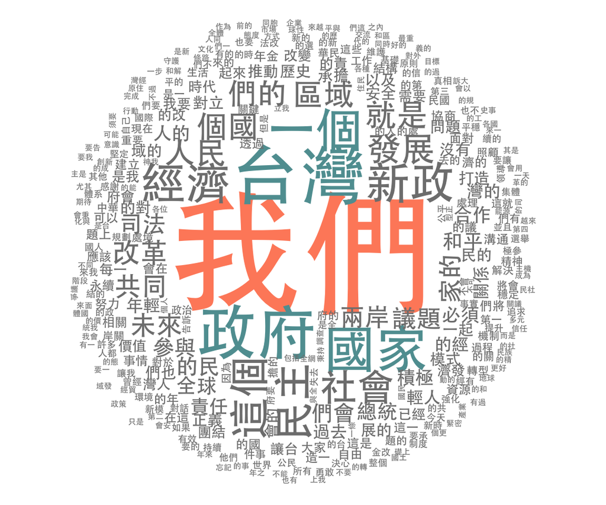

```r
> par(family = 'STHeiti') # MAC使用者需此行程式碼才能顯示中文字
> wordcloud(d$word, d$freq, scale=c(8,.2),min.freq=3,
+           max.words=Inf, random.order=FALSE,
+           colors=c("#7F7F7F", "#5F9EA0", "#FF8C69"))
```